# Homework 2

Statistical Learning - UC3M

Marina Gómez Rey

12-2022

Let’s clean our workspace before beginning.

```r
rm(list=ls())
```

**Include the Dataset**

First of all, all the necessary libraries are going to be added.

```r
#Cleaning
library(tidyr)
library(dplyr)
library(mice)
library(tidyverse)
library(skimr)
library(forcats)
library(VIM)

#Graphs
library(ggplot2)
library(GGally)

#LDA and QDA
library(MASS)
library(pROC)
library(caret)

# Decision trees
library(rpart)
library(rpart.plot)

#Random Forest
library(randomForest)

#Gradient boosting
library(gbm)
library(xgboost)

#KNN
library(class)

#Logistic regression
library(leaflet)
library(olsrr)
library(mltools)
library(jtools)
library(elasticnet)
library(glmnet)
```

Now, the dataset is included. As there may be some blank spaces in the dataset that are not considered as Nas, it is important to include the na.strings part so the cleaning can then be done in a better way.

```r
data <- read.csv("spotify.csv", header=T, na.strings=c("","NA"), sep = "")
```

# Introduction

**Motivation**

The dataset was extracted from kaggle, and it can be accessed through the following link: https://www.kaggle.com/datasets/yamaerenay/spotify-dataset-19212020-600k-tracks?select=tracks.csv - Although the original dataset has 600,000 values, I decided to reduce it to 120,000 approximately as the tools are very time consuming and rendering the file could take more than three days. I did the separation with the data partition taking into account the values of popularity, and I observed that the probabilities almost did not change, so I left it this way.

Nowadays, music is more and more listened to online, rather than in physical media such as CDs. One of the most used platforms to listen to music is Spotify, which has a catalog of more than 35 million songs from all around the world. That is why using the information about some characteristics of the songs, we can predict if a song is going to be popular or not, and which are the aspects that make a song to be considered more popular. The dataset has approximately 120000 values, which is a very large value from where we can draw many conclusions.

**The dataset**

Let’s display the head of the dataset to see what variables it has.

```r
head(data)
```

```
##                       id                                 name popularity
## 1 021ht4sdgPcrDgSk7JTbKY CapÃtulo 2.16 - Banquero Anarquista          0
## 2 07A5yehtSnoedViJAZkNnc   Vivo para Quererte - Remasterizado          0
## 3 0kCB1bDVBC8gWCFcnJyIZc                   Ca C'est Une Chose          0
## 4 0wA4YFw7ZNnpasfjVgJxpv CapÃtulo 1.22 - Banquero Anarquista          0
## 5 1KxCqUwjiAHw7W0IIrRUwP CapÃtulo 2.20 - Banquero Anarquista          0
## 6 1QDTYyfndMN9SDtRKDv9XO                         Pas Pour Moi          0
##   duration_ms explicit               artists                 id_artists
## 1       98200        0   ['Fernando Pessoa'] ['14jtPCOoNZwquk5wd9DxrY']
## 2      181640        0   ['Ignacio Corsini'] ['5LiOoJbxVSAMkBS2fUm3X2']
## 3      188000        0    ['Victor Boucher'] ['7vVR02JJYvsEAEPNHQMx0Q']
## 4      109100        0   ['Fernando Pessoa'] ['14jtPCOoNZwquk5wd9DxrY']
## 5       99800        0   ['Fernando Pessoa'] ['14jtPCOoNZwquk5wd9DxrY']
## 6      204773        0 ['Maurice Chevalier'] ['3QXjI80udwDSEfxK5BjUXc']
##   release_date danceability energy key loudness mode speechiness acousticness
## 1   1922-06-01        0.695  0.263   0  -22.136    1      0.9570        0.797
## 2   1922-03-21        0.434  0.177   1  -21.180    1      0.0512        0.994
## 3         1922        0.352  0.334   5  -13.038    1      0.0594        0.996
## 4   1922-06-01        0.704  0.244   0  -25.353    1      0.9590        0.728
## 5   1922-06-01        0.717  0.202   5  -22.807    1      0.9670        0.700
## 6         1922        0.532  0.375   7  -13.321    1      0.2980        0.995
##   instrumentalness liveness valence   tempo time_signature
## 1         0.00e+00    0.148   0.655 102.009              1
## 2         2.18e-02    0.212   0.457 130.418              5
## 3         7.46e-03    0.360   0.414  76.403              4
## 4         0.00e+00    0.168   0.644  84.489              3
## 5         0.00e+00    0.294   0.683  81.640              4
## 6         1.22e-06    0.276   0.508  80.379              4
```

The dataset has the following variables:

- duration_ms <- which is the length of the song in miliseconds.
- explicit <- 0 for no and 1 for yes.
- release_date <- which has the date including the day and month if known.
- popularity <- from 0 to 100, tells how much people like that song.

The rest of the variable’s information has been drawn from the Spotify’s API documentation :

- acousticness : A confidence measure from 0.0 to 1.0 of whether the track is acoustic. 1.0 represents high confidence the track is acoustic.
- danceability : Danceability describes how suitable a track is for dancing based on a combination of musical elements including tempo, rhythm stability, beat strength, and overall regularity. A value of 0.0 is least danceable and 1.0 is most danceable.
- duration_ms : The duration of the track in milliseconds. energy : Energy is a measure from 0.0 to 1.0 and represents a perceptual measure of intensity and activity. Typically, energetic tracks feel fast, loud, and noisy. For example, death metal has high energy, while a Bach prelude scores low on the scale. Perceptual features contributing to this attribute include dynamic range, perceived loudness, timbre, onset rate, and general entropy.
- instrumentalness : Predicts whether a track contains no vocals. “Ooh” and “aah” sounds are treated as instrumental in this context. Rap or spoken word tracks are clearly “vocal”. The closer the instrumentalness value is to 1.0, the greater likelihood the track contains no vocal content. Values above 0.5 are intended to represent instrumental tracks, but confidence is higher as the value approaches 1.0.
- key : The key the track is in. Integers map to pitches using standard Pitch Class notation . E.g. 0 = C, 1 = C♯/D♭, 2 = D, and so on.
- liveness : Detects the presence of an audience in the recording. Higher liveness values represent an increased probability that the track was performed live. A value above 0.8 provides strong likelihood that the track is live.
- loudness : The overall loudness of a track in decibels (dB). Loudness values are averaged across the entire track and are useful for comparing relative loudness of tracks. Loudness is the quality of a sound that is the primary psychological correlate of physical strength (amplitude). Values typical range between -60 and 0 db.
- mode : Mode indicates the modality (major or minor) of a track, the type of scale from which its melodic content is derived. Major is represented by 1 and minor is 0.
- speechiness : Speechiness detects the presence of spoken words in a track. The more exclusively speech-like the recording (e.g. talk show, audio book, poetry), the closer to 1.0 the attribute value. Values above 0.66 describe tracks that are probably made entirely of spoken words. Values between 0.33 and 0.66 describe tracks that may contain both music and speech, either in sections or layered, including such cases as rap music. Values below 0.33 most likely represent music and other non-speech-like tracks.
- tempo : The overall estimated tempo of a track in beats per minute (BPM). In musical terminology, tempo is the speed or pace of a given piece and derives directly from the average beat duration.
- time_signature : An estimated overall time signature of a track. The time signature (meter) is a notational convention to specify how many beats are in each bar (or measure).
- valence : A measure from 0.0 to 1.0 describing the musical positiveness conveyed by a track. Tracks with high valence sound more positive (e.g. happy, cheerful, euphoric), while tracks with low valence sound more negative (e.g. sad, depressed, angry).

```r
str(data)
```

```
## 'data.frame':    117336 obs. of  20 variables:
##  $ id              : chr  "021ht4sdgPcrDgSk7JTbKY" "07A5yehtSnoedViJAZkNnc" "0kCB1bDVBC8gWCFcnJyIZc" "0wA4YFw7ZNnpasfjVgJxpv" ...
##  $ name            : chr  "CapÃtulo 2.16 - Banquero Anarquista" "Vivo para Quererte - Remasterizado" "Ca C'est Une Chose" "CapÃtulo 1.22 - Banquero Anarquista" ...
##  $ popularity      : int  0 0 0 0 0 0 0 0 0 0 ...
##  $ duration_ms     : int  98200 181640 188000 109100 99800 204773 138587 180253 130987 176252 ...
##  $ explicit        : int  0 0 0 0 0 0 0 0 0 0 ...
##  $ artists         : chr  "['Fernando Pessoa']" "['Ignacio Corsini']" "['Victor Boucher']" "['Fernando Pessoa']" ...
##  $ id_artists      : chr  "['14jtPCOoNZwquk5wd9DxrY']" "['5LiOoJbxVSAMkBS2fUm3X2']" "['7vVR02JJYvsEAEPNHQMx0Q']" "['14jtPCOoNZwquk5wd9DxrY']" ...
##  $ release_date    : chr  "1922-06-01" "1922-03-21" "1922" "1922-06-01" ...
##  $ danceability    : num  0.695 0.434 0.352 0.704 0.717 0.532 0.43 0.545 0.543 0.642 ...
##  $ energy          : num  0.263 0.177 0.334 0.244 0.202 0.375 0.168 0.268 0.424 0.212 ...
##  $ key             : int  0 1 5 0 5 7 7 1 5 5 ...
##  $ loudness        : num  -22.1 -21.2 -13 -25.4 -22.8 ...
##  $ mode            : int  1 1 1 1 1 1 1 1 1 0 ...
##  $ speechiness     : num  0.957 0.0512 0.0594 0.959 0.967 0.298 0.0622 0.191 0.269 0.951 ...
##  $ acousticness    : num  0.797 0.994 0.996 0.728 0.7 0.995 0.995 0.995 0.99 0.635 ...
##  $ instrumentalness: num  0.00 2.18e-02 7.46e-03 0.00 0.00 1.22e-06 9.28e-01 9.20e-01 3.79e-02 0.00 ...
##  $ liveness        : num  0.148 0.212 0.36 0.168 0.294 0.276 0.246 0.112 0.861 0.107 ...
##  $ valence         : num  0.655 0.457 0.414 0.644 0.683 0.508 0.437 0.648 0.659 0.334 ...
##  $ tempo           : num  102 130.4 76.4 84.5 81.6 ...
##  $ time_signature  : int  1 5 4 3 4 4 4 4 4 4 ...
```

At first sight, we already know that some type’s must be changed and some variables do not seem very useful.

# Data preprocessing

**Check for empty values**

If they are less than a 5% in a variable, they can be erased without any big consequence but if they are more, other actions have to be taken.

We are going to check graphically where the missing values are located.

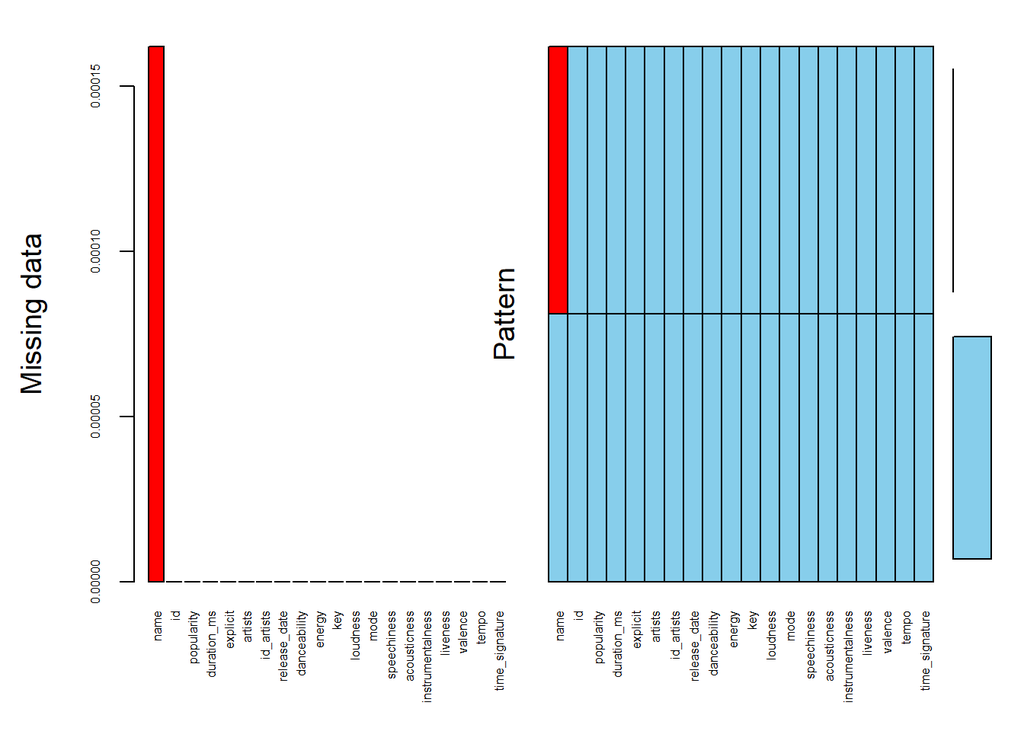

```
##
##  Variables sorted by number of missings:
##          Variable        Count
##              name 0.0001619281
##                id 0.0000000000
##        popularity 0.0000000000
##       duration_ms 0.0000000000
##          explicit 0.0000000000
##           artists 0.0000000000
##        id_artists 0.0000000000
##      release_date 0.0000000000
##      danceability 0.0000000000
##            energy 0.0000000000
##               key 0.0000000000
##          loudness 0.0000000000
##              mode 0.0000000000
##       speechiness 0.0000000000
##      acousticness 0.0000000000
##  instrumentalness 0.0000000000
##          liveness 0.0000000000
##           valence 0.0000000000
##             tempo 0.0000000000
##    time_signature 0.0000000000
```

```r
aggr(data, numbers = TRUE, sortVars = TRUE, labels = names(data),
     cex.axis = .5, gap = 1, ylab= c('Missing data','Pattern'))
```

```r
data <- data[-which(is.na(data$name)),]
```

**Erase useless columns**

There are some useless columns that can be erased, such as the ID of the songs, and the artists. Also, as the techniques we are going to use are based on numerical values, the title and the artists are not necessary.

```r
data[1] <- NULL
data[1] <- NULL
data[4] <- NULL
data[4] <- NULL
```

**Duplicates**

```r
sum(duplicated(data))
```

```
## [1] 82
```

There are 82 duplicates so they have to be erased.

```r
data <- data[!duplicated(data), ]
```

**Check variables**

The numerical values have to be checked, so that they are treated as numbers. For that reason, with the str function we applied before we can see the types of each variable and change them if necessary.

```r
data$popularity = as.numeric(data$popularity)
data$duration_ms = as.numeric(data$duration_ms)
data$explicit = as.numeric(data$explicit)
# For the date I only want the year so I only take the first four characters
data$release_date = as.numeric(substr(data$release_date, 1, 4))
data$key = as.numeric(data$key)
data$mode = as.numeric(data$mode)
data$time_signature = as.numeric(data$time_signature)
```

**Outliers**

As a first approach to outliers, which are extreme values, far from the rest, first a boxplot is computed to see visually if they seem to exist.

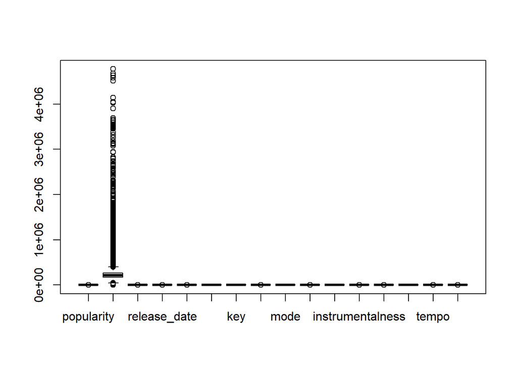

```r
boxplot(data)
```

The graph shows clearly that there exist some outliers, but to see how many, let’s apply a method that gives us how many outliers we have.

```r
outliers <- data

for (i in c(1:16)){
  value = outliers[,i][outliers[,i] %in% boxplot.stats(outliers[,i])$out]
  outliers[,i][outliers[,i] %in% value] = NA}

str(value)
```

```
##  num [1:16527] 1 5 3 3 5 3 5 3 3 3 ...
```

This method shows that there is a huge amount of outliers so let’s erase them.

```r
data <- na.omit(outliers)
```

After erasing the outliers, the following two variables do not make sense as they repeat their values so they are erased.

```r
data[3] <- NULL
data[15] <- NULL
```

# Visualization

**Popularity**

First, let’s take a look on the variable we are going to study.

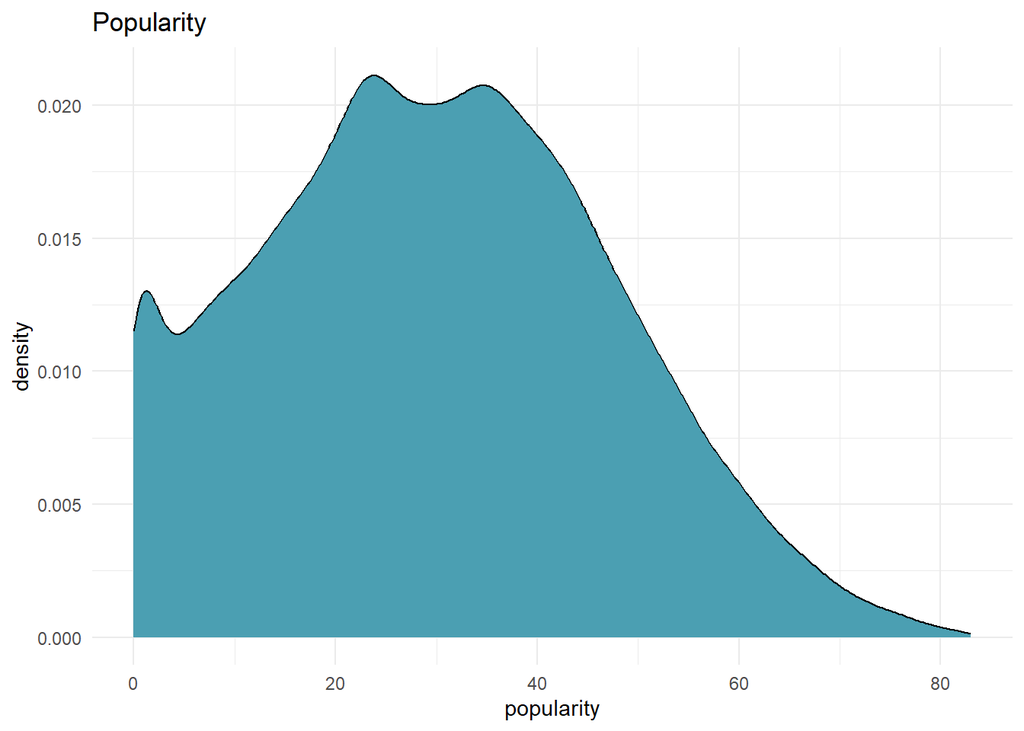

```r
ggplot(data) +
  aes(x = popularity) +
  geom_density(adjust = 1L, fill = "#4B9FB2") +
  labs(title = "Popularity") +
  theme_minimal()
```

The density graph of the popularity shows that songs with a high popularity are difficult to find, low popularities are more common but most of them are in the middle, in values between 20 and 40. Once it reaches this value, it decreases notably.

**Popularity and release_date**

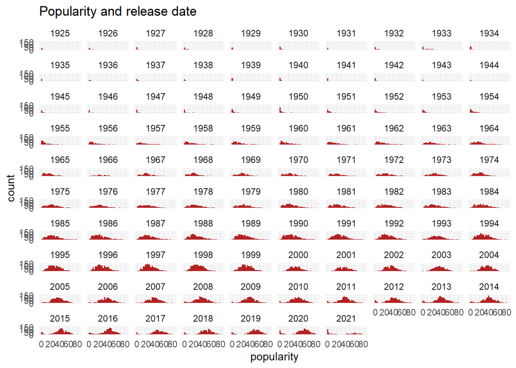

```r
ggplot(data) +
  aes(x = popularity) +
  geom_histogram(bins = 30L, fill = "#B22222") +
  labs(title = "Popularity and release date") +
  theme_minimal() +
  facet_wrap(vars(release_date))
```

As it could be expected, very old songs have very low popularities (they are less and their popularity values are also very low). However, as the years increase, these values get better. The values are specially good on 2020, maybe because of the pandemics. Also, it can be seen that from 1985, the distributions are similar to the one obtained in all the values of popularity, and they seem to get a little bit better from 2008.

**Energy, loudness and popularity**

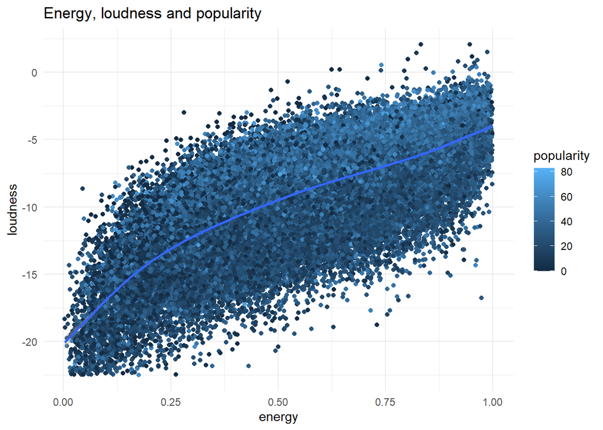

```r
ggplot(data) +
  aes(x = energy, y = loudness, colour = popularity) +
  geom_point(shape = "circle", size = 1.5) +
  geom_smooth(span = 0.75) +
  labs(title = "Energy, loudness and popularity") +
  scale_color_gradient() +
  theme_minimal()
```

A positive linear relation between energy and loudness is very clear, what makes sense as a more energetic song should be louder. However, when taking into account their relation with the popularity, they are not related as the gradient is not regular and different shadings of blue are mixed constantly, so popularity does not seem to depend on these variables. However, it is true that there seems to be better results on popularity when the energy and loudness are high, as their points are brighter, whereas the tones are darker close to point (0,0).

**Valence, danceability, key and popularity**

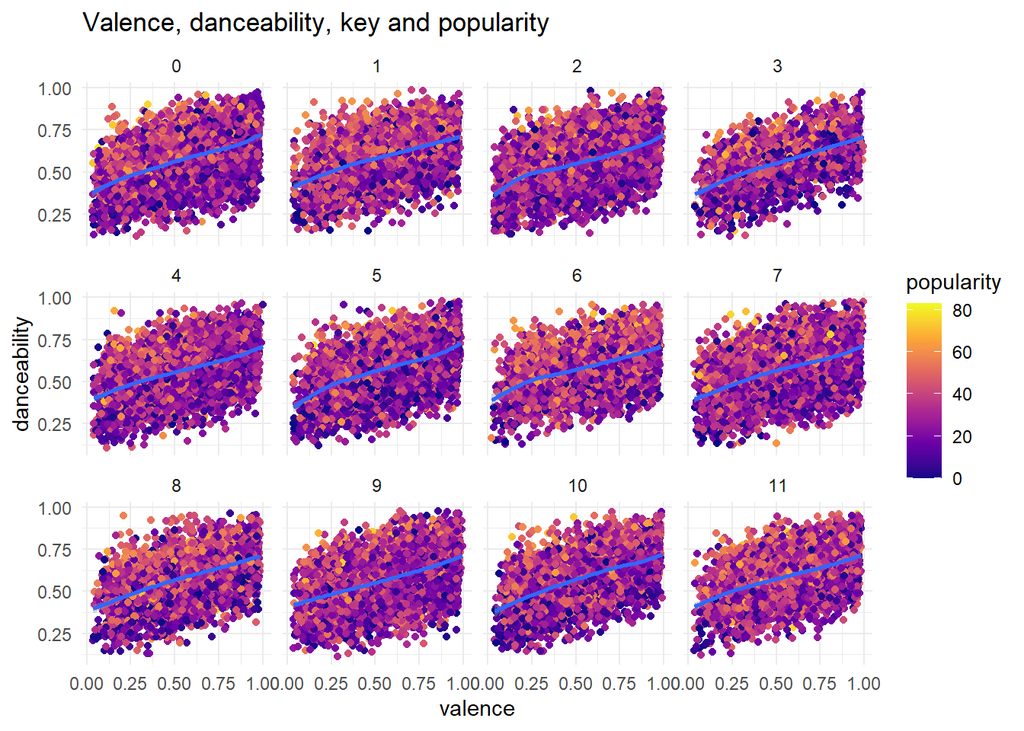

```r
ggplot(data) +
  aes(x = valence, y = danceability, colour = popularity) +
  geom_point(shape = "circle", size = 1.5) +
  geom_smooth(span = 0.75) +
  scale_color_viridis_c(option = "plasma", direction = 1) +
  labs(title = "Valence, danceability, key and popularity") +
  theme_minimal() +
  facet_wrap(vars(key))
```

This graph shows again a clear relation between danceability and valence, as valence represents the musical positiveness, it makes sense that a higher value leads to more danceability. In this case, a better value of popularity is close to a yellow tone. This suggests that there may be a slight relation between key and popularity, as it seems that 6, 8 and 11 have more presence of this colors, but it is a very slight relation. However, when comparing valence to popularity there does not seem to be a relationship because the colors are very irregular. On the contrary, it seems that higher values of danceability provide more popularity, as there are brighter tones on top than on bottom of the graphs (although it is not a very strong relationship).

**Duration, liveness, mode and popularity**

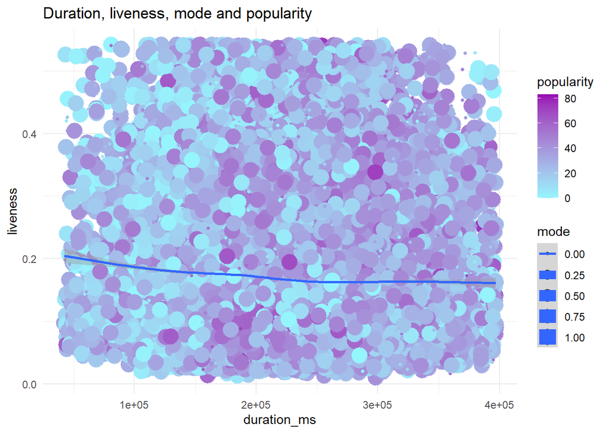

```r
ggplot(data) +
  aes(
    x = duration_ms,
    y = liveness,
    colour = popularity,
    size = mode
  ) +
  geom_point(shape = "circle") +
  geom_smooth(span = 0.75) +
  scale_color_gradient(low = "#95F5FD", high = "#9905B5") +
  labs(title = "Duration, liveness, mode and popularity") +
  theme_minimal()
```

I thought that maybe duration and liveness could be correlated as sometimes at concerts durations vary. However, it has been demonstrated through the graph that there is no correlation at all. In general, the four variables included in this graph do not seem correlated, as there are big and small points mixed and the colors are also mixed up. It does seem that there are some lighter colours at low durations, and darker on the middle of the graph but this observation does not seem very significant.

# Separating the training and test datasets

An 80% of the values of the dataset should belong to the training set, whilst the other 20% to the test set. This separation is crucial to be done in the beginning as everything except the predictions should be done with the training set. We add the seed to get always the same results.

About set seed, it did not work well unless it was added in more chunks so it will appear through the whole document.

```r
set.seed(123)

spl = createDataPartition(data$popularity, p = 0.8, list = FALSE)

dataTrain = data[spl,]
dataTest = data[-spl,]
```

**Analysis of the created sets**

Let’s analyse the groups to see that they are balanced.

As a first approach, some boxplots of the variable we are going to study are created, and then the summaries of both are computed.

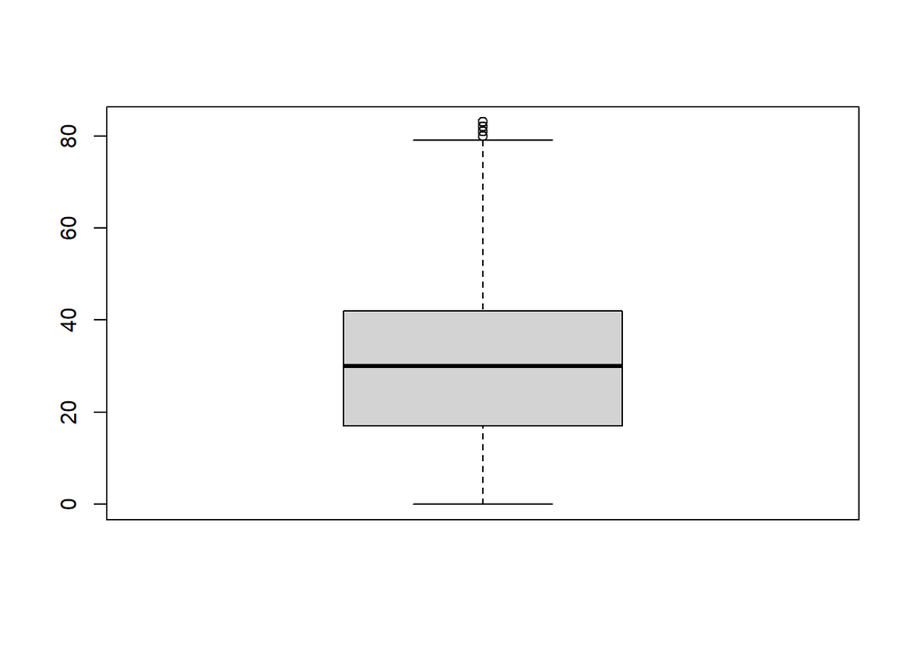

```r
boxplot(dataTrain$popularity)
```

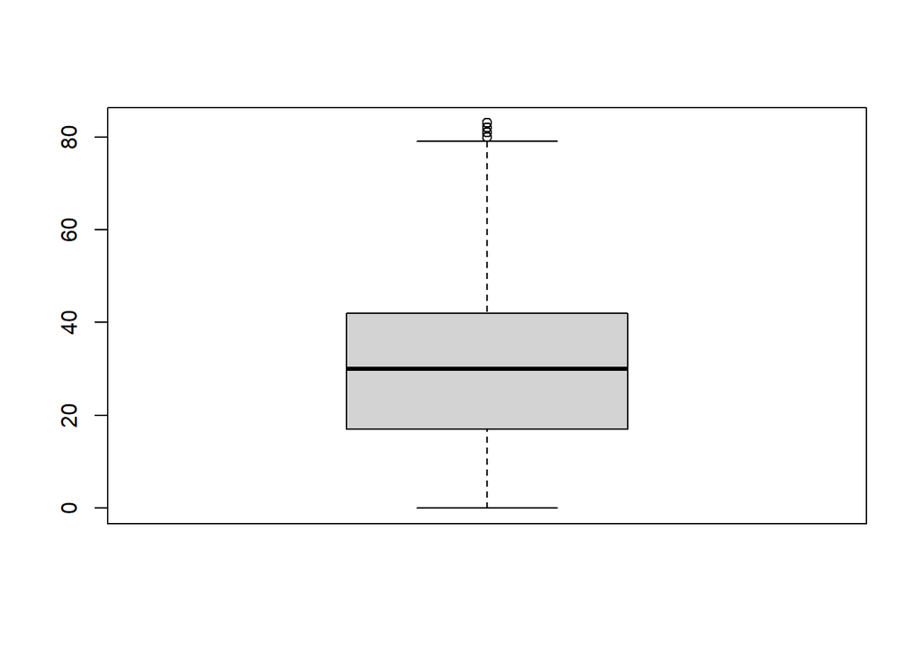

```r
boxplot(dataTest$popularity)
```

```r
summary(dataTrain)
```

```
##    popularity     duration_ms      release_date   danceability
##  Min.   : 0.00   Min.   : 42989   Min.   :1925   Min.   :0.1060
##  1st Qu.:17.00   1st Qu.:184600   1st Qu.:1980   1st Qu.:0.4890
##  Median :30.00   Median :220280   Median :1995   Median :0.5940
##  Mean   :30.11   Mean   :223727   Mean   :1992   Mean   :0.5853
##  3rd Qu.:42.00   3rd Qu.:260040   3rd Qu.:2008   3rd Qu.:0.6900
##  Max.   :83.00   Max.   :396933   Max.   :2021   Max.   :0.9860
##      energy             key            loudness            mode
##  Min.   :0.00292   Min.   : 0.000   Min.   :-22.466   Min.   :0.000
##  1st Qu.:0.41100   1st Qu.: 2.000   1st Qu.:-11.402   1st Qu.:0.000
##  Median :0.58900   Median : 5.000   Median : -8.361   Median :1.000
##  Mean   :0.57976   Mean   : 5.213   Mean   : -8.935   Mean   :0.673
##  3rd Qu.:0.76400   3rd Qu.: 8.000   3rd Qu.: -6.046   3rd Qu.:1.000
##  Max.   :1.00000   Max.   :11.000   Max.   :  2.076   Max.   :1.000
##   speechiness       acousticness      instrumentalness       liveness
##  Min.   :0.02160   Min.   :1.80e-06   Min.   :0.0000000   Min.   :0.0101
##  1st Qu.:0.03180   1st Qu.:8.74e-02   1st Qu.:0.0000000   1st Qu.:0.0931
##  Median :0.03910   Median :3.43e-01   Median :0.0000046   Median :0.1280
##  Mean   :0.04772   Mean   :3.93e-01   Mean   :0.0011738   Mean   :0.1692
##  3rd Qu.:0.05490   3rd Qu.:6.76e-01   3rd Qu.:0.0002140   3rd Qu.:0.2280
##  Max.   :0.13900   Max.   :9.96e-01   Max.   :0.0246000   Max.   :0.5420
##     valence           tempo
##  Min.   :0.0222   Min.   : 35.73
##  1st Qu.:0.3850   1st Qu.: 97.96
##  Median :0.6050   Median :118.90
##  Mean   :0.5889   Mean   :118.90
##  3rd Qu.:0.8040   3rd Qu.:136.00
##  Max.   :1.0000   Max.   :197.87
```

```r
summary(dataTest)
```

```
##    popularity     duration_ms      release_date   danceability
##  Min.   : 0.00   Min.   : 42493   Min.   :1925   Min.   :0.1250
##  1st Qu.:17.00   1st Qu.:184014   1st Qu.:1980   1st Qu.:0.4860
##  Median :30.00   Median :220200   Median :1995   Median :0.5920
##  Mean   :30.09   Mean   :223702   Mean   :1992   Mean   :0.5843
##  3rd Qu.:42.00   3rd Qu.:259987   3rd Qu.:2008   3rd Qu.:0.6880
##  Max.   :83.00   Max.   :396947   Max.   :2021   Max.   :0.9780
##      energy             key            loudness            mode
##  Min.   :0.00956   Min.   : 0.000   Min.   :-22.471   Min.   :0.0000
##  1st Qu.:0.40850   1st Qu.: 2.000   1st Qu.:-11.381   1st Qu.:0.0000
##  Median :0.58900   Median : 5.000   Median : -8.375   Median :1.0000
##  Mean   :0.58037   Mean   : 5.226   Mean   : -8.916   Mean   :0.6718
##  3rd Qu.:0.76500   3rd Qu.: 8.000   3rd Qu.: -5.997   3rd Qu.:1.0000
##  Max.   :0.99800   Max.   :11.000   Max.   :  2.079   Max.   :1.0000
##   speechiness       acousticness      instrumentalness       liveness
##  Min.   :0.02270   Min.   :0.000002   Min.   :0.000e+00   Min.   :0.0111
##  1st Qu.:0.03170   1st Qu.:0.084350   1st Qu.:0.000e+00   1st Qu.:0.0931
##  Median :0.03910   Median :0.342000   Median :4.480e-06   Median :0.1260
##  Mean   :0.04746   Mean   :0.392287   Mean   :1.205e-03   Mean   :0.1677
##  3rd Qu.:0.05470   3rd Qu.:0.674000   3rd Qu.:2.260e-04   3rd Qu.:0.2250
##  Max.   :0.13900   Max.   :0.996000   Max.   :2.460e-02   Max.   :0.5410
##     valence           tempo
##  Min.   :0.0334   Min.   : 35.28
##  1st Qu.:0.3850   1st Qu.: 98.10
##  Median :0.6050   Median :119.09
##  Mean   :0.5896   Mean   :119.24
##  3rd Qu.:0.8060   3rd Qu.:136.13
##  Max.   :0.9990   Max.   :197.65
```

It can be seen that both sets are very similar in all quantiles, so they are very well balanced.

# Study correlation

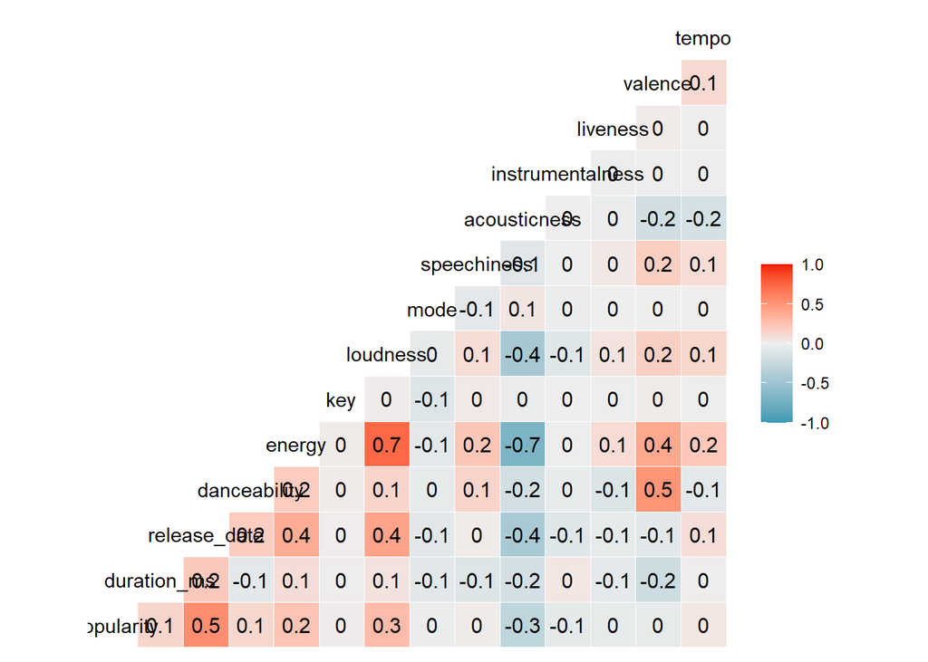

```r
ggcorr(dataTrain, label = T)
```

The correlations should be low, as in other way, variables would explain the same concepts, which would make useless some columns. In this specific case, we can see that correlations are very low, which is beneficial for us. The only two variables that have more correlation are loudness and energy, which makes sense as a louder song should be more energetic. Also, acousticness and energy have strong negative correlation. These are relations we found whith the graphs.

**Correlation with the popularity index**

Previously we saw how correlations between all the variables were, but now, we must see how variables are related to the one we are going to study, which in this case is the popularity.

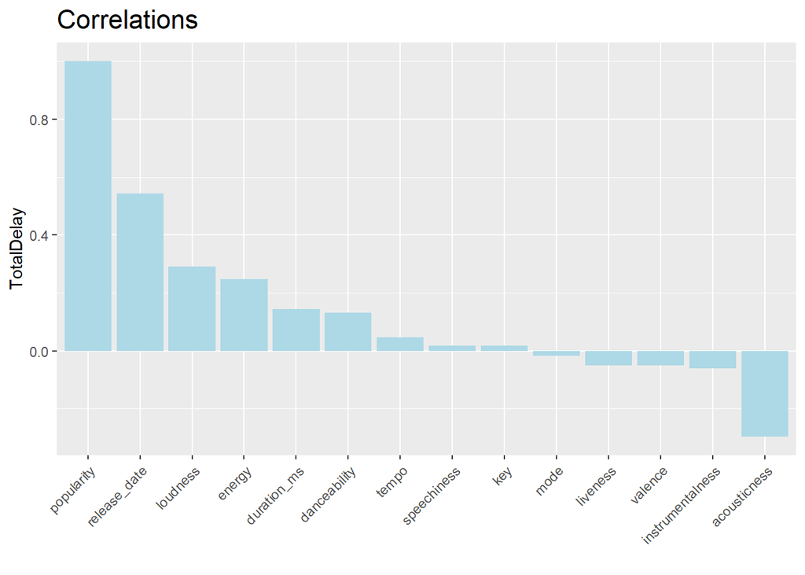

```r
corr_delay <- sort(cor(dataTrain)[1,], decreasing = T)
corr=data.frame(corr_delay)
ggplot(corr,aes(x = row.names(corr), y = corr_delay)) +
  geom_bar(stat = "identity", fill = "lightblue") +
  scale_x_discrete(limits= row.names(corr)) +
  labs(x = "", y = "TotalDelay", title = "Correlations") +
  theme(plot.title = element_text(hjust = 0, size = rel(1.5)),
        axis.text.x = element_text(angle = 45, hjust = 1))
```

# The classification approach

Classification’s aim is to find groups at our model and distinguish data classes so then a model can predict the category of objects with unknown classes.

We divide the popularity variable into three categories:

- Unpopular <- 0
- Nor popular nor unpopular <- 1
- Popular <- 2

As the values of the popularity go from 0 to 100, the intervals must be approximately of 33 units distance. However, as there are many unpopular songs, the intervals will be created from 0 to 30, then from 31 to 60 and finally from 61 to 100. Then, the popularity column is erased.

```r
data$popularityClass = factor(ifelse(data$popularity <= 30, 0,
                                     ifelse(data$popularity <= 60, 1, 2)))

data$popularity = NULL
```

Also, we have to change them in the training and test sets.

```r
dataTrain = data[spl,]
dataTest = data[-spl,]
```

**Let’s analyse the created groups**

To see if the classes are balanced let’s see how many elements are there in each group.

```r
table(dataTrain$popularityClass)
```

```
##
##     0     1     2
## 24742 21097  2114
```

Clearly, the number of elements is really irregular, being really large for the low popularity and lower for big and medium popularity.

Let’s see if they are balanced with respect to the variables. We are going to try it with the key variable.

```r
table(dataTrain$popularityClass, dataTrain$key)
```

```
##
##        0    1    2    3    4    5    6    7    8    9   10   11
##   0 3366 1256 3156  913 2181 2416 1044 3293 1237 2949 1519 1412
##   1 2711 1436 2445  655 1865 1701 1189 2617 1125 2519 1247 1587
##   2  275  183  195   68  168  195  161  224  150  194  139  162
```

They seem unbalanced, but we can see it clearer with a graph.

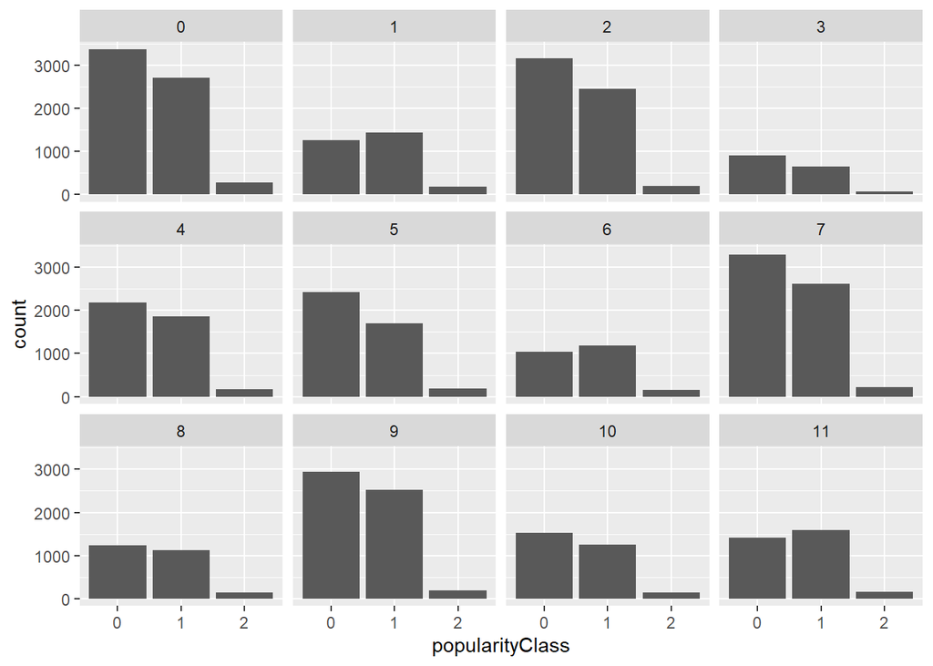

```r
ggplot(dataTrain, aes(x=popularityClass)) + geom_bar() + facet_wrap(.~key)
```

The graph shows clearly that they are not balanced, as values at not popular songs are much higher in all classes rather than popular songs.

# Bayes classifiers

## LDA

LDA (Linear Discriminant Analysis) is used for linear boundaries between classifiers.

```r
set.seed(123)

lda.model <- lda(popularityClass ~ ., data=dataTrain)
probability = predict(lda.model, newdata=dataTest)$posterior
head(probability)
```

```
##             0          1            2
## 265 0.9834166 0.01633220 0.0002512465
## 347 0.9803434 0.01930356 0.0003530203
## 357 0.9770494 0.02238677 0.0005638673
## 416 0.9750833 0.02406466 0.0008520260
## 427 0.9760818 0.02345005 0.0004681432
## 469 0.9823064 0.01748161 0.0002119608
```

With that previous code we have obtained the probabilities.

To predict the labels for delay, we apply the Bayes rule of maximum probability.

```r
set.seed(123)

prediction = predict(lda.model, newdata=dataTest)$class
head(prediction)
```

```
## [1] 0 0 0 0 0 0
## Levels: 0 1 2
```

**Performance**

The confusion matrix: has predictions in rows and the true values in columns.

```r
confusionMatrix(as.factor(prediction), dataTest$popularityClass)$table
```

```
##           Reference
## Prediction    0    1    2
##          0 4385 1582   61
##          1 1800 3692  467
##          2    0    0    0
```

```r
confusionMatrix(prediction, dataTest$popularityClass)$overall[1]
```

```
##  Accuracy
## 0.6738133
```

The accuracy we get is 0.673, which is not a very good value. For that reason, this model may not be the best for our dataset.

## QDA

Contrary to LDA, QDA (Quadratic Discriminant Analysis), does not assume linear relationships between classifiers.

```r
set.seed(123)

qda.model <- qda(popularityClass ~ ., data=dataTrain)
qda.model
```

```
## Call:
## qda(popularityClass ~ ., data = dataTrain)
##
## Prior probabilities of groups:
##          0          1          2
## 0.51596355 0.43995162 0.04408483
##
## Group means:
##   duration_ms release_date danceability    energy      key  loudness      mode
## 0    216826.0     1983.427    0.5700730 0.5342907 5.156616 -9.895349 0.6784011
## 1    231952.0     2000.519    0.5997774 0.6261428 5.275963 -8.019050 0.6674883
## 2    222422.7     2007.988    0.6197512 0.6490734 5.239357 -6.832868 0.6650899
##   speechiness acousticness instrumentalness  liveness   valence    tempo
## 0  0.04716166    0.4648304     0.0013503497 0.1727193 0.6002203 117.7701
## 1  0.04801256    0.3209146     0.0010000068 0.1662873 0.5796316 120.1843
## 2  0.05133510    0.2721319     0.0008416493 0.1570008 0.5499755 119.2727
```

**Performance**

```r
set.seed(123)

prediction = predict(qda.model, newdata=dataTest)$class
confusionMatrix(prediction, dataTest
                $popularityClass)$table
```

```
##           Reference
## Prediction    0    1    2
##          0 3761 1316   64
##          1 2419 3928  457
##          2    5   30    7
```

```r
confusionMatrix(prediction, dataTest$popularityClass)$overall[1]
```

```
##  Accuracy
## 0.6420289
```

The accuracy of QDA is less than LDA, with a value of 0,642. This would suggest that classifiers follow a linear boundary so LDA has better results.

## A benchmark model

```r
set.seed(123)

table(dataTrain$popularityClass)
```

```
##
##     0     1     2
## 24742 21097  2114
```

```r
obs <- max(table(dataTest$popularityClass))
# Accuracy:
obs/nrow(dataTest)
```

```
## [1] 0.5159756
```

The accuracy it gives is 0,515 which is low. This can happen because we have three unbalanced groups. To get a better result we can reduce the number of groups to two and make them more balanced. However, it is true that this technique gives a less precise result as we only have two ways of classifying our variable: popular or unpopular.

I am mixing the medium and high popularity classes, which were the ones that had lower values.

```r
data$popularityClass = factor(ifelse(data$popularityClass == 0, 0, 1))
```

The training and test sets must also be updated.

```r
dataTrain = data[spl,]
dataTest = data[-spl,]
```

Let’s see if the groups are more balanced.

```r
table(dataTrain$popularityClass)
```

```
##
##     0     1
## 24742 23211
```

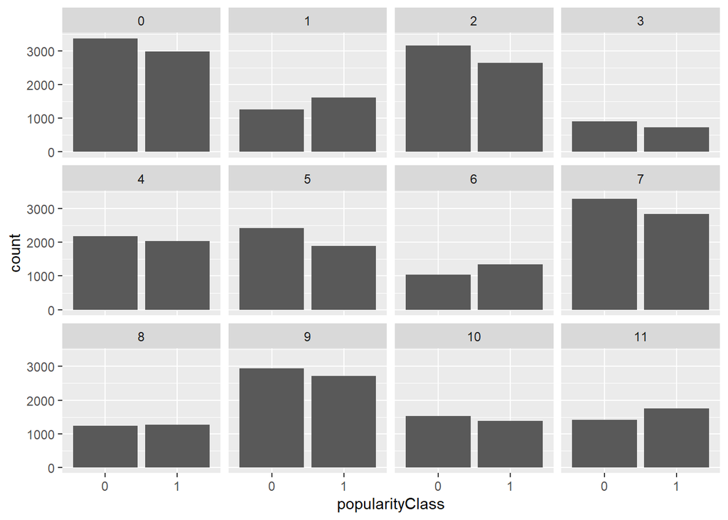

```r
ggplot(dataTrain, aes(x=popularityClass)) + geom_bar() + facet_wrap(.~key)
```

This shows clearly that groups are much more balanced, so better results are expected after this change.

Let’s compute LDA (that seemed as the best option before) again to see if the accuracy is enhanced.

```r
set.seed(123)

lda.model <- lda(popularityClass ~ ., data=dataTrain)
prediction = predict(lda.model, newdata=dataTest)$class
confusionMatrix(prediction, dataTest$popularityClass)$table
```

```
##           Reference
## Prediction    0    1
##          0 4248 1545
##          1 1937 4257
```

```r
confusionMatrix(prediction, dataTest$popularityClass)$overall[1]
```

```
##  Accuracy
## 0.7095186
```

As expected, our accuracy is now higher with a value of 0.709.

# Modeling

## Logistic regression

Logistic regression is usually computed at a binary variable, and as we changed our popularity classification to a binary one before, we can leave it like that. This technique is used to measure the relationships between the categorical variable we want to study and the rest of variables using probabilities that are obtained with logistic functions.

```r
set.seed(123)

logit.model <- glm(popularityClass ~ ., family=binomial(link='logit'), data=dataTrain)
summary(logit.model)
```

```
##
## Call:
## glm(formula = popularityClass ~ ., family = binomial(link = "logit"),
##     data = dataTrain)
##
## Deviance Residuals:
##     Min       1Q   Median       3Q      Max
## -2.1095  -0.9645  -0.2867   0.9016   2.7690
##
## Coefficients:
##                    Estimate Std. Error z value Pr(>|z|)
## (Intercept)      -1.069e+02  1.554e+00 -68.808  < 2e-16 ***
## duration_ms       1.326e-06  1.921e-07   6.903 5.09e-12 ***
## release_date      5.379e-02  7.751e-04  69.394  < 2e-16 ***
## danceability      4.480e-01  9.095e-02   4.926 8.40e-07 ***
## energy           -3.568e-01  9.801e-02  -3.640 0.000273 ***
## key               8.501e-03  2.973e-03   2.859 0.004251 **
## loudness          5.186e-02  4.522e-03  11.468  < 2e-16 ***
## mode              1.570e-01  2.246e-02   6.989 2.78e-12 ***
## speechiness       1.025e+00  4.770e-01   2.148 0.031680 *
## acousticness     -4.660e-01  4.786e-02  -9.737  < 2e-16 ***
## instrumentalness -6.399e+00  3.050e+00  -2.098 0.035913 *
## liveness         -3.266e-01  1.005e-01  -3.250 0.001154 **
## valence          -3.133e-01  5.907e-02  -5.304 1.13e-07 ***
## tempo            -2.227e-04  4.049e-04  -0.550 0.582341
## ---
## Signif. codes:  0 '***' 0.001 '**' 0.01 '*' 0.05 '.' 0.1 ' ' 1
##
## (Dispersion parameter for binomial family taken to be 1)
##
##     Null deviance: 66428  on 47952  degrees of freedom
## Residual deviance: 54464  on 47939  degrees of freedom
## AIC: 54492
##
## Number of Fisher Scoring iterations: 4
```

Once we have the model (that gives us very significant information such as the estimations, standard error, z values, etc.) we can compute the probabilities and based on how good are them, the accuracy of the model.

```r
probability <- predict(logit.model,newdata=dataTest, type='response')
head(probability)
```

```
##        265        347        357        416        427        469
## 0.01303760 0.01626767 0.01744819 0.01845733 0.01851004 0.01479865
```

```r
prediction <- as.factor(ifelse(probability > 0.5,"0","1"))
head(prediction)
```

```
## 265 347 357 416 427 469
##   1   1   1   1   1   1
## Levels: 0 1
```

```r
confusionMatrix(dataTest$popularityClass, prediction)
```

```
## Confusion Matrix and Statistics
##
##           Reference
## Prediction    0    1
##          0 1858 4327
##          1 4207 1595
##
##                Accuracy : 0.2881
##                  95% CI : (0.28, 0.2963)
##     No Information Rate : 0.506
##     P-Value [Acc > NIR] : 1.0000
##
##                   Kappa : -0.4244
##
##  Mcnemar's Test P-Value : 0.1977
##
##             Sensitivity : 0.3063
##             Specificity : 0.2693
##          Pos Pred Value : 0.3004
##          Neg Pred Value : 0.2749
##              Prevalence : 0.5060
##          Detection Rate : 0.1550
##    Detection Prevalence : 0.5160
##       Balanced Accuracy : 0.2878
##
##        'Positive' Class : 0
##
```

The accuracy of this model is 0.288 which is a very low value, so this model should not be used to predict our variable.

## ROC curve

The ROC curve (Receiver Operating Characteristic curve) is a graph that shows the performance of a classification model at all classification thresholds. It uses both True Positive Rates and False Positive Rates.

Also, the ROC curve can be computed using different models, in this case we will use the LDA model, that gave us a higher accuracy previously.

```r
set.seed(123)

model <- lda(popularityClass ~ ., data=dataTrain, prior = c(.9, .1))

probability = predict(model, dataTest)$posterior

roc.lda <- roc(dataTest$popularityClass, probability[,2])
auc(roc.lda)
```

```
## Area under the curve: 0.7791
```

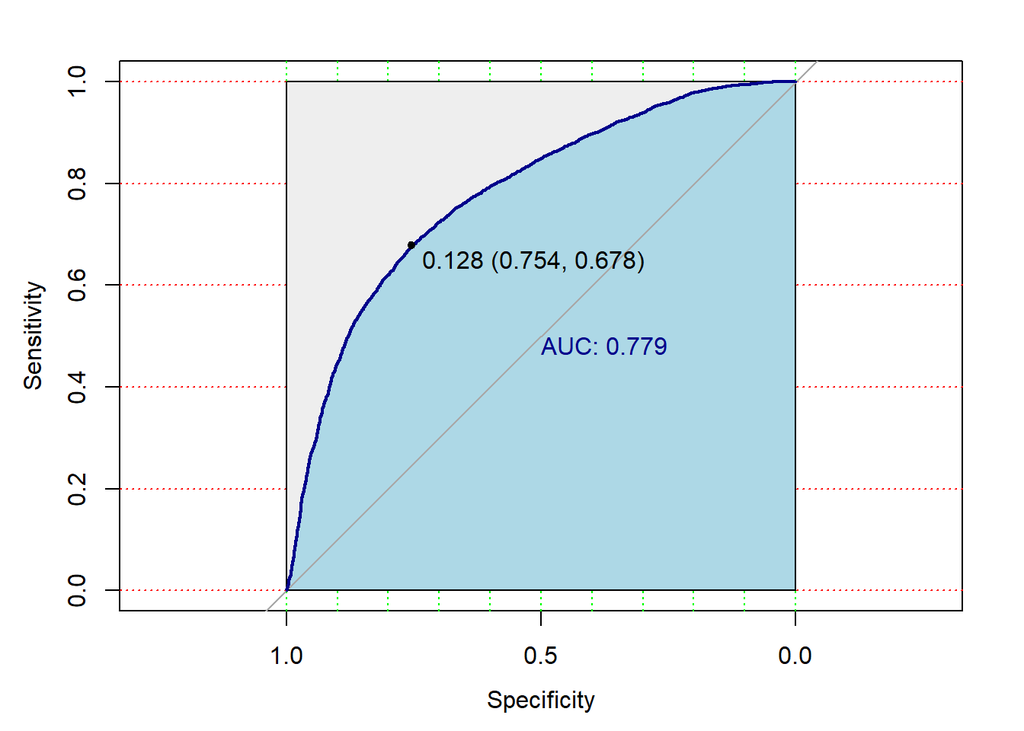

```r
plot.roc(dataTest$popularityClass, probability[,2],col="darkblue", print.auc = TRUE,  auc.polygon=TRUE, grid=c(0.1, 0.2),
         grid.col=c("green", "red"), max.auc.polygon=TRUE,
         auc.polygon.col="lightblue", print.thres=TRUE)
```

The higher the area under the curve, the better the model. The area in this case is of 0,779, which is nice. Also,it gives a threshold of 0,128.

## The benchmark

Firstly, we need to rename the factors to a name that R recognizes. We do that with the make.names function and apply them to the dataset and the training and test sets.

```r
names <- make.names(c(1, 2))

data$popularityClass <- as.factor(gsub(1, names[2], data$popularityClass))
data$popularityClass <- as.factor(gsub(0, names[1], data$popularityClass))

dataTrain <- data[spl, ]
dataTest <- data[-spl, ]
```

Now, the technique we are going to compute is the lrFit, but firstly, we compute the control variable with the number of repetitions which in this case is 5.

Then, we compute the model for lrFit, which stands for Logistic Regression, similar to generalized linear models (glm).

```r
set.seed(123)

ctrl <- trainControl(method = "cv", number = 5,
                     classProbs = TRUE,
                     verboseIter=T)

lrFit <- train(popularityClass ~ .,
               method = "glmnet",
               tuneGrid = expand.grid(alpha = seq(0, 1, 0.1), lambda = seq(0, .1, 0.02)),
               metric = "Kappa",
               data = dataTrain,
               preProcess = c("center", "scale"),
               trControl = ctrl)
print(lrFit)
```

```
## glmnet
##
## 47953 samples
##    13 predictor
##     2 classes: 'X1', 'X2'
##
## Pre-processing: centered (13), scaled (13)
## Resampling: Cross-Validated (5 fold)
## Summary of sample sizes: 38362, 38363, 38362, 38363, 38362
## Resampling results across tuning parameters:
##
##   alpha  lambda  Accuracy   Kappa
##   0.0    0.00    0.7075262  0.4151683
##   0.0    0.02    0.7075262  0.4151683
##   0.0    0.04    0.7067963  0.4137098
##   0.0    0.06    0.7057744  0.4116688
##   0.0    0.08    0.7052113  0.4105157
##   0.0    0.10    0.7045231  0.4091447
##   0.1    0.00    0.7082770  0.4166723
##   0.1    0.02    0.7071925  0.4145324
##   0.1    0.04    0.7065461  0.4132251
##   0.1    0.06    0.7060664  0.4122385
##   0.1    0.08    0.7058787  0.4118264
##   0.1    0.10    0.7056493  0.4113374
##   0.2    0.00    0.7084646  0.4170484
##   0.2    0.02    0.7070883  0.4143181
##   0.2    0.04    0.7077764  0.4156625
##   0.2    0.06    0.7070465  0.4141524
##   0.2    0.08    0.7068380  0.4136886
##   0.2    0.10    0.7068172  0.4135959
##   0.3    0.00    0.7085063  0.4171396
##   0.3    0.02    0.7076096  0.4153492
##   0.3    0.04    0.7079016  0.4158896
##   0.3    0.06    0.7076096  0.4152513
##   0.3    0.08    0.7075679  0.4151103
##   0.3    0.10    0.7078181  0.4155176
##   0.4    0.00    0.7086106  0.4173473
##   0.4    0.02    0.7082978  0.4167305
##   0.4    0.04    0.7080475  0.4161915
##   0.4    0.06    0.7079016  0.4158039
```

[output cut: 26 more lines]

```
##   0.9    0.00    0.7085481  0.4172200
##   0.9    0.02    0.7066712  0.4134971
##   0.9    0.04    0.7041270  0.4085083
##   0.9    0.06    0.7011241  0.4026273
##   0.9    0.08    0.7011658  0.4027106
##   0.9    0.10    0.7011658  0.4027106
##   1.0    0.00    0.7085064  0.4171382
##   1.0    0.02    0.7061916  0.4125718
##   1.0    0.04    0.7029175  0.4061976
##   1.0    0.06    0.7011658  0.4027106
##   1.0    0.08    0.7011658  0.4027106
##   1.0    0.10    0.7011658  0.4027106
##
## Kappa was used to select the optimal model using the largest value.
## The final values used for the model were alpha = 0.4 and lambda = 0.
```

**Prediction**

```r
lrPred = predict(lrFit, dataTest)
confusionMatrix(dataTest$popularityClass, lrPred)
```

```
## Confusion Matrix and Statistics
##
##           Reference
## Prediction   X1   X2
##         X1 4326 1859
##         X2 1593 4209
##
##                Accuracy : 0.712
##                  95% CI : (0.7038, 0.7201)
##     No Information Rate : 0.5062
##     P-Value [Acc > NIR] : < 2.2e-16
##
##                   Kappa : 0.4243
##
##  Mcnemar's Test P-Value : 6.472e-06
##
##             Sensitivity : 0.7309
##             Specificity : 0.6936
##          Pos Pred Value : 0.6994
##          Neg Pred Value : 0.7254
##              Prevalence : 0.4938
##          Detection Rate : 0.3609
##    Detection Prevalence : 0.5160
##       Balanced Accuracy : 0.7123
##
##        'Positive' Class : X1
##
```

After computing all the models with the different alphas and lambdas, the accuracy obtained for this model is 0.712, which has increased drastically in comparison with the other benchmark model.

**Variable importance**

With the model we obtained before we can obtain the variable importance.

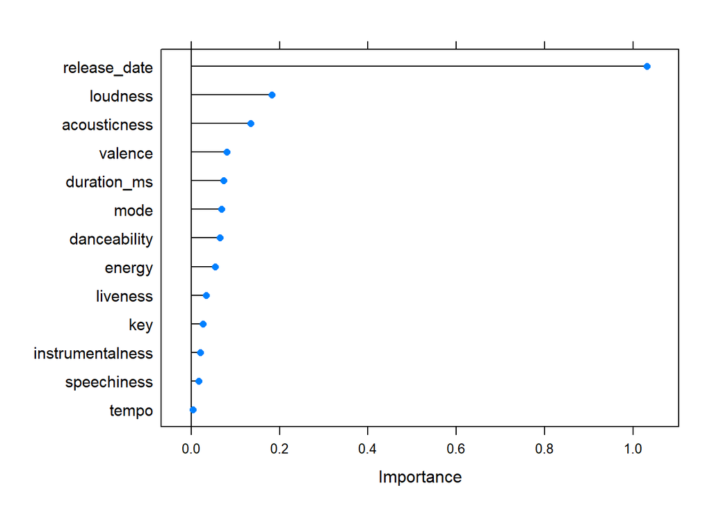

```r
lr_imp <- varImp(lrFit, scale = F)
plot(lr_imp, scales = list(y = list(cex = .95)))
```

The most important variable is the release date, that was the most correlated variable with the popularity in the graph we show in the beginning. After that, we can see that the importance of the rest of the variables decreases drastically. Regardless of that, the next most important variable is the loudness (which refers to dB of the song), which has a similar importance to acousticness (which represents if a song has electronic instruments).

On the other hand, the least important ones are tempo (speed of the song), key (tone of the song), instrumentalness (if it has vocals), liveness (if it was performed live), energy and speechiness (presence of spoken words).

**ROC curve**

As we saw before, the ROC curve can be computed using different methods, so we are going to compute it again using the model we obtained in the benchmark.

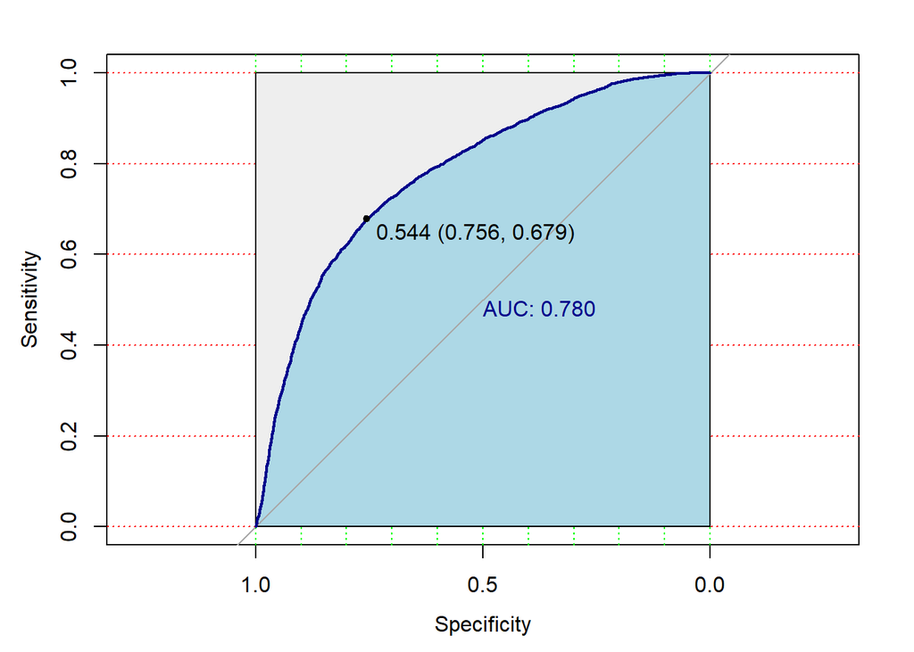

```r
set.seed(123)

lrProb = predict(lrFit, dataTest, type="prob")

plot.roc(dataTest$popularityClass, lrProb[,2],col="darkblue", print.auc = TRUE,  auc.polygon=TRUE, grid=c(0.1, 0.2),
         grid.col=c("green", "red"), max.auc.polygon=TRUE,
         auc.polygon.col="lightblue", print.thres=TRUE)
```

This model gives a similar area to the other one (0.78). However, the threshold gives a different value (as the benchmark was better for this one, I am going to conserve this one). Now, we are going to compute the accuracy with the new threshold the ROC has given.

```r
set.seed(123)

threshold = 0.54
lrProb = predict(lrFit, dataTest, type="prob")
lrPred = rep(names[1], nrow(dataTest))
lrPred[which(lrProb[,2] > threshold)] = names[2]
confusionMatrix(factor(lrPred), dataTest$popularityClass)
```

```
## Confusion Matrix and Statistics
##
##           Reference
## Prediction   X1   X2
##         X1 4646 1849
##         X2 1539 3953
##
##                Accuracy : 0.7174
##                  95% CI : (0.7092, 0.7254)
##     No Information Rate : 0.516
##     P-Value [Acc > NIR] : < 2.2e-16
##
##                   Kappa : 0.4332
##
##  Mcnemar's Test P-Value : 1.104e-07
##
##             Sensitivity : 0.7512
##             Specificity : 0.6813
##          Pos Pred Value : 0.7153
##          Neg Pred Value : 0.7198
##              Prevalence : 0.5160
##          Detection Rate : 0.3876
##    Detection Prevalence : 0.5418
##       Balanced Accuracy : 0.7162
##
##        'Positive' Class : X1
##
```

It gives an accuracy of 0,717 which is a nice value, higher than the previous ones.

## Cost sensitive

When creating a model, it is also very important to take into account the cost of it, as if the accuracies are similar, it is always better to take a model that is less consuming. For that reason, we are also going to take into account if the models are very consuming or not.

In this case, the taken values for the cost are between 0 and 500, so if the final value is close to 0 it would be much better than close to 500, which is very consuming.

We are going to use the model used in the benchmark.

```r
set.seed(123)

cost.i = matrix(NA, nrow = 100, ncol = 10)

cost.unit <- c(0, 100, 500, 140)

j <- 0
for (threshold in seq(0.05,0.5,0.05)){

  j <- j + 1
  cat(j)
  for(i in 1:100){

    d <- createDataPartition(dataTrain$popularityClass, p = 0.8, list = FALSE)

    train <- data[d,]
    test  <- data[-d,]

    lrFit <- train(popularityClass ~ ., data=train, method = "glmnet",
                   tuneGrid = data.frame(alpha = 0.3, lambda = 0), preProcess = c("center", "scale"),
                   trControl = trainControl(method = "none", classProbs = TRUE))

    lrProb = predict(lrFit, test, type="prob")
    lrPred = rep(names[1], nrow(test))
    lrPred[which(lrProb[,2] > threshold)] = names[2]

    CM = confusionMatrix(factor(lrPred), test$popularityClass)$table
    cost = sum(as.vector(CM)*cost.unit)/sum(CM)
    cost

    cost.i[i,j] <- cost

  }
}
```

```
## 12345678910
```

Now, let’s see the cost of the model.

```r
set.seed(123)

threshold = 0.54
lrFit <- train(popularityClass ~ ., data=dataTrain, method = "glmnet",
               tuneGrid = data.frame(alpha = 0.3, lambda = 0), preProcess = c("center", "scale"),
               trControl = trainControl(method = "none", classProbs = TRUE))
lrProb = predict(lrFit, dataTest, type="prob")
lrPred = rep(names[1], nrow(dataTest))
lrPred[which(lrProb[,2] > threshold)] = names[2]
CM = confusionMatrix(factor(lrPred), dataTest$popularityClass)$table
CM
```

```
##           Reference
## Prediction   X1   X2
##         X1 4646 1851
##         X2 1539 3951
```

```r
cost = sum(as.vector(CM)*cost.unit)/sum(CM)
cost
```

```
## [1] 136.1925
```

The cost is of 136.19, which is not a veru high value compared to 500 but could be lower.

# Machine learning tools

Machine learning tools give us the possibility to predict the studied variable taking into account the values of the rest of the variables.

## Decision trees

With a decision tree we can see which variables are more decisive when looking for a popular song and we can predict if a song is going to be popular or not based on its paths.

Decision trees require some hyperparameters: minsplit, which is the minimum number of observations on each iteration; maxdepth, which is the maximum depth the tree can go up to and cp, which is the complexity parameter and controls the tree size. The hyperparameters are established in the control and then added to the model.

First, let’s compute a first approach with the rpart function.

```r
set.seed(123)

control = rpart.control(minsplit = 30, maxdepth = 10, cp=0.01)

model = popularityClass ~.
dtFit <- rpart(model, data=dataTrain, method = "class", control = control)
summary(dtFit)
```

```
## Call:
## rpart(formula = model, data = dataTrain, method = "class", control = control)
##   n= 47953
##
##          CP nsplit rel error    xerror        xstd
## 1 0.4053251      0 1.0000000 1.0000000 0.004714793
## 2 0.0100000      1 0.5946749 0.5946749 0.004271499
##
## Variable importance
## release_date     loudness       energy acousticness danceability
##           70           20            5            3            1
##
## Node number 1: 47953 observations,    complexity param=0.4053251
##   predicted class=X1  expected loss=0.4840365  P(node) =1
##     class counts: 24742 23211
##    probabilities: 0.516 0.484
##   left son=2 (29185 obs) right son=3 (18768 obs)
##   Primary splits:
##       release_date < 1999.5   to the left,  improve=4383.6300, (0 missing)
##       loudness     < -7.7505  to the left,  improve=1424.2490, (0 missing)
##       acousticness < 0.5445   to the right, improve=1014.1800, (0 missing)
##       energy       < 0.5735   to the left,  improve= 781.5490, (0 missing)
##       duration_ms  < 176746.5 to the left,  improve= 608.7171, (0 missing)
##   Surrogate splits:
##       loudness     < -7.0465  to the left,  agree=0.722, adj=0.290, (0 split)
##       energy       < 0.7605   to the left,  agree=0.636, adj=0.069, (0 split)
##       acousticness < 0.1295   to the right, agree=0.626, adj=0.045, (0 split)
##       danceability < 0.7995   to the left,  agree=0.615, adj=0.016, (0 split)
##       speechiness  < 0.1045   to the left,  agree=0.609, adj=0.001, (0 split)
##
## Node number 2: 29185 observations
##   predicted class=X1  expected loss=0.3125921  P(node) =0.6086168
##     class counts: 20062  9123
##    probabilities: 0.687 0.313
##
## Node number 3: 18768 observations
##   predicted class=X2  expected loss=0.2493606  P(node) =0.3913832
##     class counts:  4680 14088
##    probabilities: 0.249 0.751
```

Now, let’s compute it graphically.

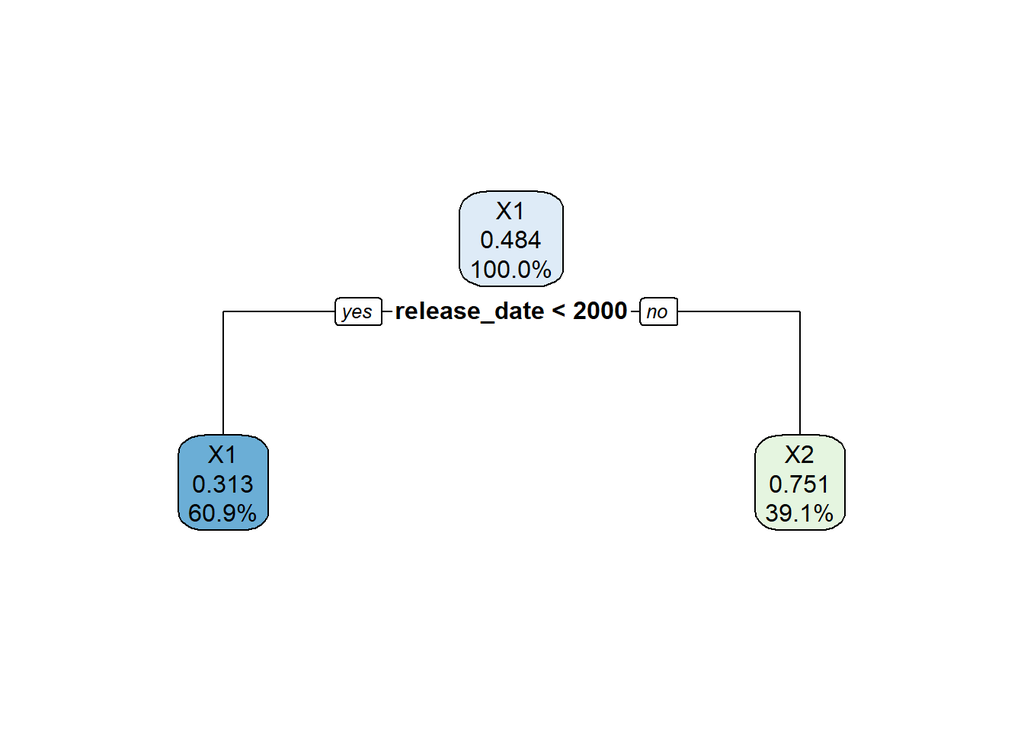

```r
rpart.plot(dtFit, digits=3)
```

As we saw in the variable importance before, the most decisive variable is the date. As expected, if the song is very old its popularity is not going to be very high. In this case, it makes the distinction in the year 2000.

As this tree was very small and did not have many information as has very few levels, a bigger tree with a higher maxdepth can be obtained to be more precise with the classification.

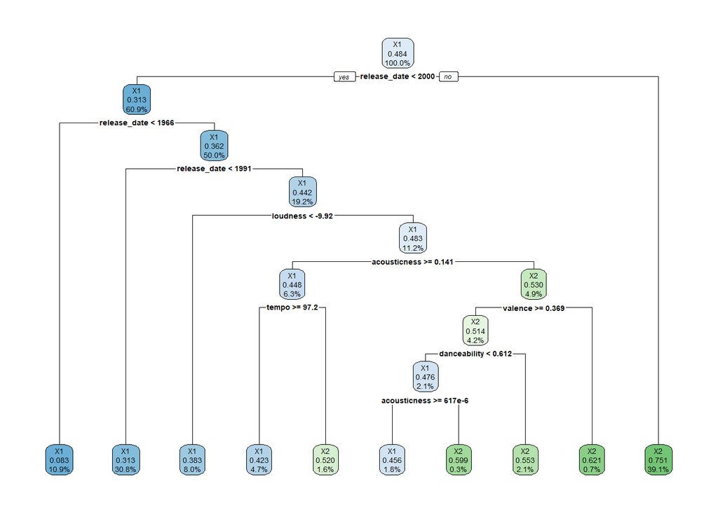

```r
set.seed(123)

control = rpart.control(minsplit = 40, maxdepth = 12, cp=0.001)
dtFit <- rpart(model, data=dataTrain, method = "class", control = control)

rpart.plot(dtFit, digits = 3)
```

**Prediction**

For the prediction, we are going to take into account both the accuracy and the cost to create the most optimal model.

```r
dtPred <- predict(dtFit, dataTest, type = "class")
dtProb <- predict(dtFit, dataTest, type = "prob")

threshold = 0.54
dtPred = rep(names[1], nrow(dataTest))
dtPred[which(dtProb[,2] > threshold)] = names[2]

CM = confusionMatrix(factor(dtPred), dataTest$popularityClass)$table
confusionMatrix(factor(dtPred), dataTest$popularityClass)
```

```
## Confusion Matrix and Statistics
##
##           Reference
## Prediction   X1   X2
##         X1 4869 1983
##         X2 1316 3819
##
##                Accuracy : 0.7248
##                  95% CI : (0.7167, 0.7328)
##     No Information Rate : 0.516
##     P-Value [Acc > NIR] : < 2.2e-16
##
##                   Kappa : 0.447
##
##  Mcnemar's Test P-Value : < 2.2e-16
##
##             Sensitivity : 0.7872
##             Specificity : 0.6582
##          Pos Pred Value : 0.7106
##          Neg Pred Value : 0.7437
##              Prevalence : 0.5160
##          Detection Rate : 0.4062
##    Detection Prevalence : 0.5716
##       Balanced Accuracy : 0.7227
##
##        'Positive' Class : X1
##
```

```r
cost = sum(as.vector(CM)*cost.unit)/sum(CM)
cost
```

```
## [1] 138.2965
```

The accuracy this model gives is 0.724, and the cost is approximately 138.29, which are nice values but will be lately compared to see if they are optimum.

**Caret package**

Regardless of the previous results, we are going to compute again the decision tree but using this time the caret package.

```r
set.seed(123)

caret.fit <- train(model,
                   data = dataTrain,
                   method = "rpart",
                   control=rpart.control(minsplit = 40, maxdepth = 12),
                   trControl = trainControl(method = "cv", number = 5),
                   tuneLength=10)
caret.fit
```

```
## CART
##
## 47953 samples
##    13 predictor
##     2 classes: 'X1', 'X2'
##
## No pre-processing
## Resampling: Cross-Validated (5 fold)
## Summary of sample sizes: 38362, 38363, 38362, 38363, 38362
## Resampling results across tuning parameters:
##
##   cp            Accuracy   Kappa
##   0.0004739132  0.7145747  0.4269042
##   0.0004954547  0.7146999  0.4271285
##   0.0006031623  0.7151378  0.4281262
##   0.0007324114  0.7134278  0.4245779
##   0.0007754944  0.7138032  0.4253319
##   0.0008832019  0.7136989  0.4251790
##   0.0010555340  0.7142411  0.4263655
##   0.0013355737  0.7137406  0.4249034
##   0.0014863642  0.7137406  0.4249034
##   0.4053250614  0.5926605  0.1645100
##
## Accuracy was used to select the optimal model using the largest value.
## The final value used for the model was cp = 0.0006031623.
```

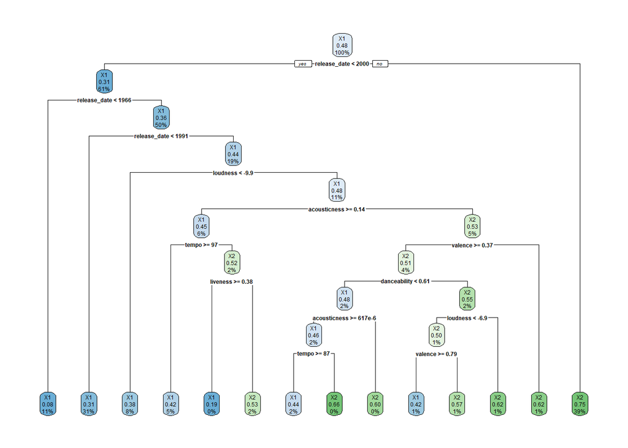

```r
rpart.plot(caret.fit$finalModel)
```

As it can be observed in the plot, it has more ramifications so it should be more precise than the one we obtained before. Regardless of this, the variables are very similar to the ones in the branches of the other model (as expected). It also gives a lot of importance to the release date, having various high branches dedicated to it. After that, we can also encounter the acousticness (higher than before), loudness, danceability and valence. However, this tree introduces some variable that were not present before, such as tempo.

**Prediction of the caret model**

Let’s compute the prediction of this model to see if this package performs better.

```r
set.seed(123)

dtProb <- predict(caret.fit, dataTest, type = "prob")
threshold = 0.54
dtPred = rep(names[1], nrow(dataTest))
dtPred[which(dtProb[,2] > threshold)] = names[2]
CM = confusionMatrix(factor(dtPred), dataTest$popularityClass)$table
confusionMatrix(factor(dtPred), dataTest$popularityClass)
```

```
## Confusion Matrix and Statistics
##
##           Reference
## Prediction   X1   X2
##         X1 4895 2019
##         X2 1290 3783
##
##                Accuracy : 0.724
##                  95% CI : (0.7159, 0.7319)
##     No Information Rate : 0.516
##     P-Value [Acc > NIR] : < 2.2e-16
##
##                   Kappa : 0.4452
##
##  Mcnemar's Test P-Value : < 2.2e-16
##
##             Sensitivity : 0.7914
##             Specificity : 0.6520
##          Pos Pred Value : 0.7080
##          Neg Pred Value : 0.7457
##              Prevalence : 0.5160
##          Detection Rate : 0.4084
##    Detection Prevalence : 0.5768
##       Balanced Accuracy : 0.7217
##
##        'Positive' Class : X1
##
```

```r
cost = sum(as.vector(CM)*cost.unit)/sum(CM)
cost
```

```
## [1] 139.1608
```

## Random Forest

Random Forest is a technique that creates a high number of trees and combines them. Again, it needs some hyperparameters: the number of trees is kept in the ntree hyperparameter and the number of random variables that are chosen on each iteration is kept in the mtry variable.

```r
set.seed(123)

rf.train <- randomForest(popularityClass ~., data=dataTrain, ntree=200,mtry=10,cutoff=c(0.75,0.25),importance=TRUE, do.trace=T)
```

```
## ntree      OOB      1      2
##     1:  37.36% 35.29% 39.58%
##     2:  37.23% 39.91% 34.38%
##     3:  37.61% 44.26% 30.53%
##     4:  37.92% 48.13% 27.05%
##     5:  38.02% 51.19% 24.05%
##     6:  38.00% 53.36% 21.70%
##     7:  37.84% 54.61% 20.05%
##     8:  37.83% 55.63% 18.91%
##     9:  37.79% 56.59% 17.77%
##    10:  37.78% 57.13% 17.15%
##    11:  37.56% 57.33% 16.51%
##    12:  37.45% 57.63% 15.94%
##    13:  37.29% 57.91% 15.33%
##    14:  37.23% 58.28% 14.83%
```

[output cut: 186 more lines]

**Prediction**

```r
rf.pred <- predict(rf.train, newdata=dataTest)
confusionMatrix(rf.pred, dataTest$popularityClass)
```

```
## Confusion Matrix and Statistics
##
##           Reference
## Prediction   X1   X2
##         X1 1992  311
##         X2 4193 5491
##
##                Accuracy : 0.6243
##                  95% CI : (0.6155, 0.6329)
##     No Information Rate : 0.516
##     P-Value [Acc > NIR] : < 2.2e-16
##
##                   Kappa : 0.263
##
##  Mcnemar's Test P-Value : < 2.2e-16
##
##             Sensitivity : 0.3221
##             Specificity : 0.9464
##          Pos Pred Value : 0.8650
##          Neg Pred Value : 0.5670
##              Prevalence : 0.5160
##          Detection Rate : 0.1662
##    Detection Prevalence : 0.1921
##       Balanced Accuracy : 0.6342
##
##        'Positive' Class : X1
##
```

The accuracy it gives is of 0.624, which is lower than the decision tree obtained before. However, choosing optimal hyperparameters can increase the accuracy.

**Optimum Hyper parameters**

We are going to compute again the random forest using now the caret library, so first we are to compute the optimal hyperparameters we talked about before, and compute the cost to see if it is smaller.

```r
set.seed(123)

PopularityCost <- function(data, lev = NULL, model = NULL)
{
  y.pred = data$pred
  y.true = data$obs
  CM = confusionMatrix(y.pred, y.true)$table
  out = sum(as.vector(CM)*cost.unit)/sum(CM)
  names(out) <- c("EconomicCost")
  out
}

ctrl <- trainControl(method = "cv", number = 5,
                     classProbs = TRUE,
                     summaryFunction = PopularityCost,
                     verboseIter=T)

PopularityCost(data = data.frame(pred  = rf.pred, obs = dataTest$popularityClass))
```

```
## EconomicCost
##     112.0831
```

The cost of this model is of 112.08, which is considerably smaller than the decision trees. Now, we compute again the random forest, but using this time the previously created function.

```r
set.seed(123)

rf.train <- train(popularityClass ~.,
                  method = "rf",
                  data = dataTrain,
                  preProcess = c("center", "scale"),
                  ntree = 200,
                  cutoff=c(0.7,0.3),
                  tuneGrid = expand.grid(mtry=c(6,8,10)),
                  metric = "PopularityCost",
                  maximize = F,
                  trControl = ctrl)
```

**Variable importance**

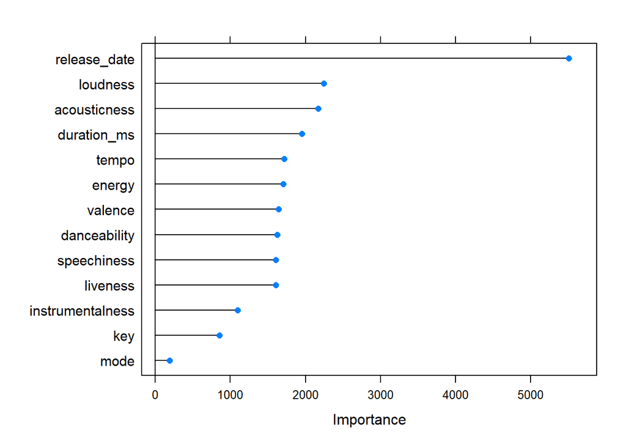

```r
rf_imp <- varImp(rf.train, scale = F)
plot(rf_imp, scales = list(y = list(cex = .95)))
```

The results obtained in the plot are very similar to the other variable importance plot that has been obtained with the previous model. However, it seems that the difference between the date and the rest of the variables is a less pronounced.

**Prediction**

The prediction is going to be obtained in two ways, the first one takes into account the hyperparameters, and the other the threshold.

```r
rfPred = predict(rf.train, newdata=dataTest)
CM = confusionMatrix(factor(rfPred), dataTest$popularityClass)$table
confusionMatrix(factor(rfPred), dataTest$popularityClass)
```

```
## Confusion Matrix and Statistics
##
##           Reference
## Prediction   X1   X2
##         X1 2501  491
##         X2 3684 5311
##
##                Accuracy : 0.6517
##                  95% CI : (0.6431, 0.6602)
##     No Information Rate : 0.516
##     P-Value [Acc > NIR] : < 2.2e-16
##
##                   Kappa : 0.3144
##
##  Mcnemar's Test P-Value : < 2.2e-16
##
##             Sensitivity : 0.4044
##             Specificity : 0.9154
##          Pos Pred Value : 0.8359
##          Neg Pred Value : 0.5904
##              Prevalence : 0.5160
##          Detection Rate : 0.2086
##    Detection Prevalence : 0.2496
##       Balanced Accuracy : 0.6599
##
##        'Positive' Class : X1
##
```

```r
cost = sum(as.vector(CM)*cost.unit)/sum(CM)
cost
```

```
## [1] 113.2427
```

Taking into account the hyperparameters, the accuracy is of 0.651 and the cost of 113.24.

```r
threshold = 0.54
rfProb = predict(rf.train, newdata=dataTest, type="prob")
rfPred = rep(names[1], nrow(dataTest))
rfPred[which(rfProb[,2] > threshold)] = names[2]
CM = confusionMatrix(factor(rfPred), dataTest$popularityClass)$table
confusionMatrix(factor(rfPred), dataTest$popularityClass)
```

```
## Confusion Matrix and Statistics
##
##           Reference
## Prediction   X1   X2
##         X1 5004 2083
##         X2 1181 3719
##
##                Accuracy : 0.7277
##                  95% CI : (0.7196, 0.7357)
##     No Information Rate : 0.516
##     P-Value [Acc > NIR] : < 2.2e-16
##
##                   Kappa : 0.4522
##
##  Mcnemar's Test P-Value : < 2.2e-16
##
##             Sensitivity : 0.8091
##             Specificity : 0.6410
##          Pos Pred Value : 0.7061
##          Neg Pred Value : 0.7590
##              Prevalence : 0.5160
##          Detection Rate : 0.4175
##    Detection Prevalence : 0.5912
##       Balanced Accuracy : 0.7250
##
##        'Positive' Class : X1
##
```

```r
cost = sum(as.vector(CM)*cost.unit)/sum(CM)
cost
```

```
## [1] 140.1735
```

However, when taking into account the threshold, the cost increases considerably to 140.17 and the accuracy also increases to 0.727.

These results suggest that the best random forest model is the one that uses the best hyperparameters with the caret library (as expected), and the prediction using the threshold is better.

## Gradient Boosting

Gradient Boosting is a technique that uses a combination of weak learners, in this case decision trees, to create a strong predictive model. The generation of the trees is made sequentially, in a way that the new tree solutes the errors the previous tree had. Also, the generated trees are not very deep, with normally no more than three levels.

As the other two techniques, gradient boosting also has hyperparameters, in this case they are: n.trees, which is the number of trees created; shrinkage, which helps modifying the update rule; interaction.depth, which are the number of splits on each tree; and n.minobsinnode, which is the minimum number of observations in trees terminal nodes.

**Training**

Let’s do a first approach with the information stated before.

```r
set.seed(123)

GBM.train <- gbm(ifelse(dataTrain$popularityClass==names[1],0,1) ~., data=dataTrain, distribution= "bernoulli",n.trees=250,shrinkage = 0.01,interaction.depth=2,n.minobsinnode = 8)
```

**Prediction and cost**

The cost and the accuracy of the model are obtained.

```r
threshold = 0.54
gbmProb = predict(GBM.train, newdata=dataTest, n.trees=250, type="response")
gbmPred = rep(names[1], nrow(dataTest))
gbmPred[which(gbmProb > threshold)] = names[2]
CM = confusionMatrix(factor(gbmPred), dataTest$popularityClass)$table
confusionMatrix(factor(gbmPred), dataTest$popularityClass)
```

```
## Confusion Matrix and Statistics
##
##           Reference
## Prediction   X1   X2
##         X1 5036 2204
##         X2 1149 3598
##
##                Accuracy : 0.7203
##                  95% CI : (0.7122, 0.7283)
##     No Information Rate : 0.516
##     P-Value [Acc > NIR] : < 2.2e-16
##
##                   Kappa : 0.4368
##
##  Mcnemar's Test P-Value : < 2.2e-16
##
##             Sensitivity : 0.8142
##             Specificity : 0.6201
##          Pos Pred Value : 0.6956
##          Neg Pred Value : 0.7580
##              Prevalence : 0.5160
##          Detection Rate : 0.4201
##    Detection Prevalence : 0.6040
##       Balanced Accuracy : 0.7172
##
##        'Positive' Class : X1
##
```

```r
cost = sum(as.vector(CM)*cost.unit)/sum(CM)
cost
```

```
## [1] 143.5405
```

With the previous model, we have an accuracy of 0.72, and a cost of 143.54. These are not bad values but the value of the cost is one of the highest.

**Caret**

Now, we are going to compute another approach using the caret package.

This model requires different hyperparameters that are kept at the grid, and used at the training.

```r
set.seed(123)

xgb_grid = expand.grid(
  nrounds = c(500,1000),
  eta = c(0.01, 0.001),
  max_depth = c(2, 4, 6),
  gamma = 1,
  colsample_bytree = c(0.2, 0.4),
  min_child_weight = c(1,5),
  subsample = 1
)
```

**Training**

```r
set.seed(123)

xgb.train = train(popularityClass ~ .,  data=dataTrain,
                  trControl = ctrl,
                  metric="EconomicCost",
                  maximize = F,
                  tuneGrid = xgb_grid,
                  preProcess = c("center", "scale"),
                  method = "xgbTree"
)
```

[output not shown]

[output cut: 186 more lines]

[output not shown]

**Variable importance**

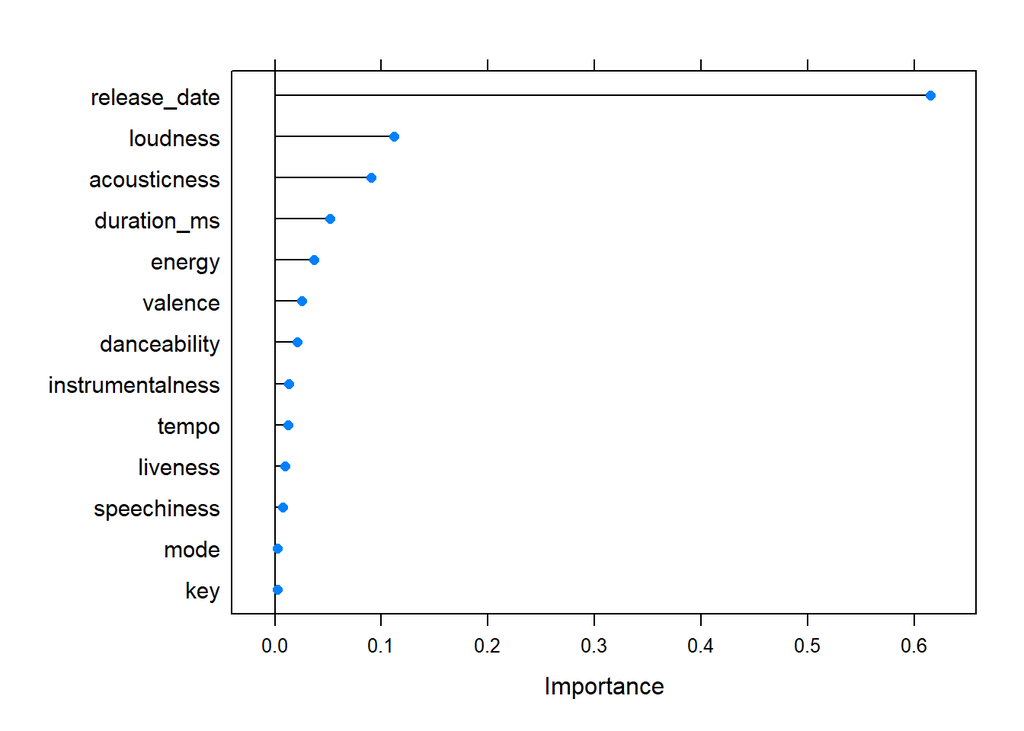

```r
xgb_imp <- varImp(xgb.train, scale = F)
plot(xgb_imp, scales = list(y = list(cex = .95)))
```

These results are practically the same to the first variable importance plot created.

**Prediction and cost**

```r
threshold = 0.54
xgbProb = predict(xgb.train, newdata=dataTest, type="prob")
xgbPred = rep(names[1], nrow(dataTest))
xgbPred[which(xgbProb[,2] > threshold)] = names[2]
CM = confusionMatrix(factor(xgbPred), dataTest$popularityClass)$table
confusionMatrix(factor(xgbPred), dataTest$popularityClass)
```

```
## Confusion Matrix and Statistics
##
##           Reference
## Prediction   X1   X2
##         X1 5198 2436
##         X2  987 3366
##
##                Accuracy : 0.7144
##                  95% CI : (0.7063, 0.7225)
##     No Information Rate : 0.516
##     P-Value [Acc > NIR] : < 2.2e-16
##
##                   Kappa : 0.4238
##
##  Mcnemar's Test P-Value : < 2.2e-16
##
##             Sensitivity : 0.8404
##             Specificity : 0.5801
##          Pos Pred Value : 0.6809
##          Neg Pred Value : 0.7733
##              Prevalence : 0.5160
##          Detection Rate : 0.4336
##    Detection Prevalence : 0.6369
##       Balanced Accuracy : 0.7103
##
##        'Positive' Class : X1
##
```

```r
cost = sum(as.vector(CM)*cost.unit)/sum(CM)
cost
```

```
## [1] 149.1566
```

The accuracy of this model is of 0.714, slightly worse than the other, and a cost of 149.15, which is higher than the other. For that reason, the other model should be used as it is better and less costly.

## Subsampling Techniques

Subsampling is a technique that instead of taking the whole dataset takes a sample of it. I have chosen the up-sampling, which randomly samples with replacement the minority class to be the same size as the majority class.

```r
set.seed(123)

ctrl$sampling <- "up"

rf.train <- train(popularityClass ~.,
                  method = "rf",
                  data = dataTrain,
                  preProcess = c("center", "scale"),
                  ntree = 200,
                  cutoff=c(0.7,0.3),
                  tuneGrid = expand.grid(mtry=c(6,8,10)),
                  importance=TRUE,
                  metric = "PopularityCost",
                  maximize = F,
                  trControl = ctrl)
```

**Prediction and cost**

```r
threshold = 0.54
rfProb = predict(rf.train, newdata=dataTest, type="prob")
rfPred = rep(names[1], nrow(dataTest))
rfPred[which(rfProb[,2] > threshold)] = names[2]
CM = confusionMatrix(factor(rfPred), dataTest$popularityClass)$table
confusionMatrix(factor(rfPred), dataTest$popularityClass)
```

```
## Confusion Matrix and Statistics
##
##           Reference
## Prediction   X1   X2
##         X1 4965 2091
##         X2 1220 3711
##
##                Accuracy : 0.7238
##                  95% CI : (0.7157, 0.7318)
##     No Information Rate : 0.516
##     P-Value [Acc > NIR] : < 2.2e-16
##
##                   Kappa : 0.4444
##
##  Mcnemar's Test P-Value : < 2.2e-16
##
##             Sensitivity : 0.8027
##             Specificity : 0.6396
##          Pos Pred Value : 0.7037
##          Neg Pred Value : 0.7526
##              Prevalence : 0.5160
##          Detection Rate : 0.4142
##    Detection Prevalence : 0.5886
##       Balanced Accuracy : 0.7212
##
##        'Positive' Class : X1
##
```

```r
cost = sum(as.vector(CM)*cost.unit)/sum(CM)
cost
```

```
## [1] 140.7391
```

The accuracy gives as a result 0.7238, which is slightly better than the previous technique, but the cost is of 140.73, which is a little bit high.

## Basic ensembles

Ensemble combines the models that were obtained previously to create a new one.

```r
set.seed(123)

mode <- function(v) {
  uniqv <- unique(v)
  uniqv[which.max(tabulate(match(v, uniqv)))]
}
```

**Prediction and cost**

```r
ensemble.pred = apply(data.frame(lrPred, xgbPred, rfPred), 1, mode)
CM = confusionMatrix(factor(ensemble.pred), dataTest$popularityClass)$table
confusionMatrix(factor(ensemble.pred), dataTest$popularityClass)
```

```
## Confusion Matrix and Statistics
##
##           Reference
## Prediction   X1   X2
##         X1 4989 2122
##         X2 1196 3680
##
##                Accuracy : 0.7232
##                  95% CI : (0.7151, 0.7312)
##     No Information Rate : 0.516
##     P-Value [Acc > NIR] : < 2.2e-16
##
##                   Kappa : 0.4431
##
##  Mcnemar's Test P-Value : < 2.2e-16
##
##             Sensitivity : 0.8066
##             Specificity : 0.6343
##          Pos Pred Value : 0.7016
##          Neg Pred Value : 0.7547
##              Prevalence : 0.5160
##          Detection Rate : 0.4162
##    Detection Prevalence : 0.5932
##       Balanced Accuracy : 0.7204
##
##        'Positive' Class : X1
##
```

```r
cost = sum(as.vector(CM)*cost.unit)/sum(CM)
cost
```

```
## [1] 141.4699
```

The accuracy of this model is of 0.723, very similar to the previous one, and a cost of 141.46, a little bit bigger (although ensemble is a technique that is usually very costly).

## Conclusion

After converting our numerical variable into a categorical one, it has been shown that having well-balanced groups is important to have better results. Regarding the models, the got accuracies are around 0.7, that although could be better (our variables are not very correlated so it is normal) they are not bad values.

The best obtained model has been the random forest with the optimal hyperparameters as it gives the highest accuracy and also not a very high cost. On the other hand, the worst model was the gradient boosting, as it was very consuming compared to its accuracy.

# Model selection

First, we load our dataset again and create the training and test sets.

```r
rm(list=ls())

set.seed(123)

data <- read.csv("spotify.csv", header=T, na.strings=c("","NA"), sep = "")

data[1] <- NULL
data[1] <- NULL
data[4] <- NULL
data[4] <- NULL

data <- data[!duplicated(data), ]

data$popularity = as.numeric(data$popularity)
data$duration_ms = as.numeric(data$duration_ms)
data$explicit = as.numeric(data$explicit)
data$release_date = as.numeric(substr(data$release_date, 1, 4))
data$key = as.numeric(data$key)
data$mode = as.numeric(data$mode)
data$time_signature = as.numeric(data$time_signature)

outliers <- data

for (i in c(1:16)){
  value = outliers[,i][outliers[,i] %in% boxplot.stats(outliers[,i])$out]
  outliers[,i][outliers[,i] %in% value] = NA}

data <- na.omit(outliers)

data[3] <- NULL
data[15] <- NULL

spl = createDataPartition(data$popularity, p = 0.8, list = FALSE)

dataTrain = data[spl,]
dataTest = data[-spl,]
```

We create a first approach of the model by adding some variables, and then we are going to analyse it to see which ones we can erase. I decided not to add all the variables because when trying the combinations the process becomes very time consuming, so I added the ones that are the most correlated with the popularity, as they should give a higher R-squared.

```r
model <- popularity ~ energy + danceability + loudness + release_date + acousticness + instrumentalness + speechiness + duration_ms
linFit <- lm(model, data=dataTrain)
```

**Analysis**

Let’s apply different techniques to create the best possible model.

As a first approach, we apply this one where all the combinations are tried to see which one gives the highest R-squared.

```r
ols_step_all_possible(linFit)
```

```
##     Index N
## 4       1 1
## 5       2 1
## 3       3 1
## 1       4 1
## 8       5 1
## 2       6 1
## 6       7 1
## 7       8 1
## 27      9 2
## 22     10 2
## 11     11 2
## 30     12 2
## 17     13 2
## 28     14 2
```

[output cut: 753 more lines]

We can see that the highest R-squared corresponds to the last value, that is the combination of all the selected values, but as there are some values that are very similar, let’s do further analysis.

```r
ols_step_best_subset(linFit)
```

```
##                                            Best Subsets Regression
## --------------------------------------------------------------------------------------------------------------
## Model Index    Predictors
## --------------------------------------------------------------------------------------------------------------
##      1         release_date
##      2         release_date acousticness
##      3         loudness release_date acousticness
##      4         energy loudness release_date acousticness
##      5         energy loudness release_date acousticness duration_ms
##      6         energy danceability loudness release_date acousticness duration_ms
##      7         energy danceability loudness release_date acousticness instrumentalness duration_ms
##      8         energy danceability loudness release_date acousticness instrumentalness speechiness duration_ms
## --------------------------------------------------------------------------------------------------------------
##
##                                                             Subsets Regression Summary
## ---------------------------------------------------------------------------------------------------------------------------------------------------
##                        Adj.        Pred
## Model    R-Square    R-Square    R-Square      C(p)          AIC           SBIC            SBC            MSEP           FPE        HSP       APC
## ---------------------------------------------------------------------------------------------------------------------------------------------------
##   1        0.2933      0.2933      0.2932    668.0361    392542.5277    256449.2401    392568.8618    10074836.1647    210.0938    0.0044    0.7068
##   2        0.2983      0.2983      0.2982    323.4067    392201.4079    256108.1357    392236.5200    10003217.7099    208.6046    0.0044    0.7018
##   3        0.3005      0.3004      0.3003    179.7090    392058.4492    255965.1881    392102.3394     9973234.1970    207.9837    0.0043    0.6997
##   4        0.3018      0.3017      0.3017     89.0534    391968.0352    255874.7862    392020.7035     9954241.2906    207.5919    0.0043    0.6983
##   5        0.3025      0.3024      0.3023     44.1201    391923.1563    255829.9157    391984.6026     9944722.7726    207.3978    0.0043    0.6977
##   6        0.3030      0.3029      0.3028     10.6635    391889.7103    255796.4787    391959.9347     9937582.2448    207.2532    0.0043    0.6972
##   7        0.3031      0.3030      0.3028      8.7570    391887.8033    255794.5732    391966.8057     9936979.9038    207.2449    0.0043    0.6972
##   8        0.3031      0.3030      0.3028      9.0000    391888.0461    255794.8169    391975.8265     9936823.0351    207.2460    0.0043    0.6972
## ---------------------------------------------------------------------------------------------------------------------------------------------------
## AIC: Akaike Information Criteria
##  SBIC: Sawa's Bayesian Information Criteria
##  SBC: Schwarz Bayesian Criteria
##  MSEP: Estimated error of prediction, assuming multivariate normality
##  FPE: Final Prediction Error
##  HSP: Hocking's Sp
##  APC: Amemiya Prediction Criteria
```

The values of R-squared are very similar for models 6, 7 and 8 in this case, so we can see which is the best model with the value of AIC (Akaike Information Criteria). If this value is smaller, it represents better our variable. In this case, the best model would be the seventh model, which takes out speechiness.

To see the value we have just studied (AIC) better, we can compute the following analysis.

```r
ols_step_forward_aic(linFit)
```

```
##
##                                   Selection Summary
## -------------------------------------------------------------------------------------
## Variable               AIC          Sum Sq           RSS          R-Sq      Adj. R-Sq
## -------------------------------------------------------------------------------------
## release_date        392542.528    4181060.606    10074415.995    0.29330      0.29328
## acousticness        392201.408    4252884.670    10002591.931    0.29833      0.29830
## loudness            392058.449    4283074.278     9972402.323    0.30045      0.30041
## energy              391968.035    4302273.174     9953203.426    0.30180      0.30174
## duration_ms         391923.156    4311998.076     9943478.524    0.30248      0.30241
## danceability        391889.710    4319344.938     9936131.663    0.30300      0.30291
## instrumentalness    391887.803    4320154.406     9935322.195    0.30305      0.30295
## -------------------------------------------------------------------------------------
```

We can do another analysis that will tell us if it would erase any variable.

```r
ols_step_backward_aic(linFit)
```

```
##
##
##                           Backward Elimination Summary
## -------------------------------------------------------------------------------
## Variable          AIC            RSS          Sum Sq        R-Sq      Adj. R-Sq
## -------------------------------------------------------------------------------
## Full Model     391888.046    9934958.141    4320518.460    0.30308      0.30296
## speechiness    391887.803    9935322.195    4320154.406    0.30305      0.30295
## -------------------------------------------------------------------------------
```

Based on this, this model would erase the speechiness as one of the least representative.

Finally, we can join both AIC analysis in the following command.

```r
ols_step_both_aic(linFit)
```

```
##
##
##                                          Stepwise Summary
## -------------------------------------------------------------------------------------------------
## Variable             Method        AIC            RSS           Sum Sq        R-Sq      Adj. R-Sq
## -------------------------------------------------------------------------------------------------
## release_date        addition    392542.528    10074415.995    4181060.606    0.29330      0.29328
## acousticness        addition    392201.408    10002591.931    4252884.670    0.29833      0.29830
## loudness            addition    392058.449     9972402.323    4283074.278    0.30045      0.30041
## energy              addition    391968.035     9953203.426    4302273.174    0.30180      0.30174
## duration_ms         addition    391923.156     9943478.524    4311998.076    0.30248      0.30241
## danceability        addition    391889.710     9936131.663    4319344.938    0.30300      0.30291
## instrumentalness    addition    391887.803     9935322.195    4320154.406    0.30305      0.30295
## -------------------------------------------------------------------------------------------------
```

This gives as a result the same conclusions that were drowned from the previous two analysis. Also, the speechiness variable does not appear.

As a final conclusion to the analysis, I believe that every command gave as a result that the best model is the one that was introduced in the beginning without the speechiness variable as this model gives the best results in all the different methods.

```r
linFit <- lm(popularity ~ energy + danceability + loudness + release_date + acousticness + instrumentalness + duration_ms, data = dataTrain)
summary(linFit)
```

```
##
## Call:
## lm(formula = popularity ~ energy + danceability + loudness +
##     release_date + acousticness + instrumentalness + duration_ms,
##     data = dataTrain)
##
## Residuals:
##     Min      1Q  Median      3Q     Max
## -46.550  -9.440  -0.635   8.971  62.605
##
## Coefficients:
##                    Estimate Std. Error  t value Pr(>|t|)
## (Intercept)      -8.138e+02  8.127e+00 -100.136  < 2e-16 ***
## energy           -5.296e+00  5.395e-01   -9.817  < 2e-16 ***
## danceability      2.766e+00  4.679e-01    5.911 3.42e-09 ***
## loudness          4.221e-01  2.717e-02   15.533  < 2e-16 ***
## release_date      4.262e-01  4.045e-03  105.353  < 2e-16 ***
## acousticness     -4.787e+00  3.022e-01  -15.839  < 2e-16 ***
## instrumentalness -3.735e+01  1.890e+01   -1.976   0.0481 *
## duration_ms       9.037e-06  1.186e-06    7.619 2.61e-14 ***
## ---
## Signif. codes:  0 '***' 0.001 '**' 0.01 '*' 0.05 '.' 0.1 ' ' 1
##
## Residual standard error: 14.39 on 47948 degrees of freedom
## Multiple R-squared:  0.3031, Adjusted R-squared:  0.303
## F-statistic:  2978 on 7 and 47948 DF,  p-value: < 2.2e-16
```

The final R-Squared this model gives is 0.303, which is not very high. This makes sense because the variables of our dataset, as we saw at the beginning, are not very correlated what produces this low values.

## Prediction

```r
predictions <- exp(predict(linFit, newdata=dataTest))
cor(dataTest$popularity, predictions)^2
```

```
## [1] 0.00867126
```

```r
RMSE <- sqrt(mean((predictions - dataTest$popularity)^2))
RMSE
```

```
## [1] 7.044016e+18
```

## Benchmark

```r
set.seed(123)

benchFit <- lm(popularity ~ 1, data=dataTrain)
benchFit$coefficients
```

```
## (Intercept)
##    30.09115
```

```r
predictions <- predict(benchFit, newdata=dataTest)
RMSE <- sqrt(mean((predictions - dataTest$popularity)^2))
RMSE
```

```
## [1] 17.13924
```

After creating the benchmark model and trying it with the Test set, we can see that it performs way much better than the other one, with a Root Mean Square Error (RMSE) of only 17.13.

# Statistical Learning tools

## Linear Regression

**Train**

Regression is a common tool used in supervised learning, as it takes some variables and study which ones are significant predictors of the outcome variable, which is the subject of study. The simplest form of regression is linear, as it represents the data in the form of a lines with a formula y = a + b*x.

We are going to train a linear regression model using the variables we obtained before.

```r
set.seed(123)

model <- popularity ~ energy + danceability + loudness + release_date + acousticness + instrumentalness + duration_ms

ctrl <- trainControl(method = "repeatedcv",
                     number = 5, repeats = 1)

lm_tune <- train(model, data = dataTrain,
                 method = "lm",
                 preProc=c('scale', 'center'),
                 trControl = ctrl)
lm_tune
```

```
## Linear Regression
##
## 47956 samples
##     7 predictor
##
## Pre-processing: scaled (7), centered (7)
## Resampling: Cross-Validated (5 fold, repeated 1 times)
## Summary of sample sizes: 38364, 38364, 38365, 38365, 38366
## Resampling results:
##
##   RMSE      Rsquared   MAE
##   14.39548  0.3029407  11.21924
##
## Tuning parameter 'intercept' was held constant at a value of TRUE
```

With the training set, it gives a R-Squared of 0.302, and a RMSE of 14.39.

**Predict**

Now, we are going to make the prediction with the test set.

```r
set.seed(123)

test_results <- data.frame(popularity = dataTest$popularity)

test_results$lm <- predict(lm_tune, dataTest)

postResample(pred = test_results$lm,  obs = test_results$popularity)
```

```
##      RMSE  Rsquared       MAE
## 14.176098  0.315939 11.100178
```

It predicts a R-Squared of 0.315 and an error of 14.17. These results are very low and not accurate.

**Visualization**

We are going to compute graphically the results.

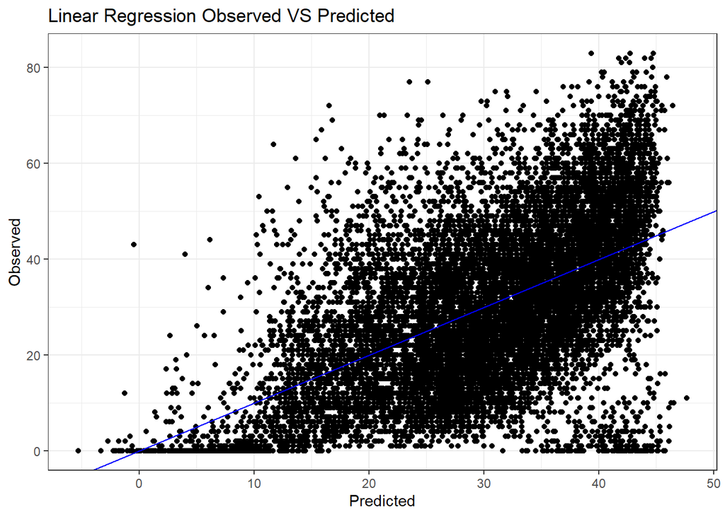

```r
qplot(test_results$lm, test_results$popularity) +
  labs(title="Linear Regression Observed VS Predicted", x="Predicted", y="Observed") +
  geom_abline(intercept = 0, slope = 1, colour = "blue") +
  theme_bw()
```

We can see that there are a lot of values because of the huge amount of data, but it can be seen that the model follows a linear model, although there is a huge bias.

## Overfitted linear regression

Overfitting is usually used when the model is too complex, usually when there are a large number of parameters compared to the number of observations.

Let’s make a model with overfitted regression and see if it behaves better than linear regression.

**Train**

```r
set.seed(123)

alm_tune <- train(model, data = dataTrain,
                  method = "lm",
                  preProc=c('scale', 'center'),
                  trControl = ctrl)
```

**Predict**

```r
set.seed(123)

test_results$alm <- predict(alm_tune, dataTest)
postResample(pred = test_results$alm,  obs = test_results$popularity)
```

```
##      RMSE  Rsquared       MAE
## 14.176098  0.315939 11.100178
```

This gives as a result a R-squared of 0.315 almost identical to non-overfitted linar regression.

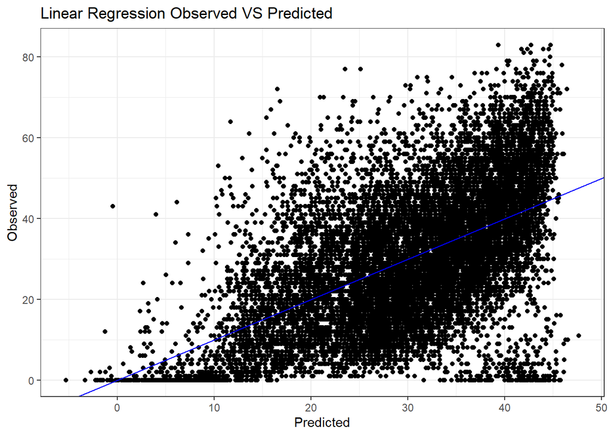

```r
set.seed(123)

qplot(test_results$alm, test_results$popularity) +
  labs(title="Linear Regression Observed VS Predicted", x="Predicted", y="Observed") +
  geom_abline(intercept = 0, slope = 1, colour = "blue") +
  theme_bw()
```

The graph is also very similar and has a huge amount of bias.

## Ridge Regression

We are going to compute the Ridge Regression with the caret package.

**Train and plot the model**

Our main objective at the ridge regression is to find the best value for lambda, and we are going to do that by obtaining the model and plotting the results.

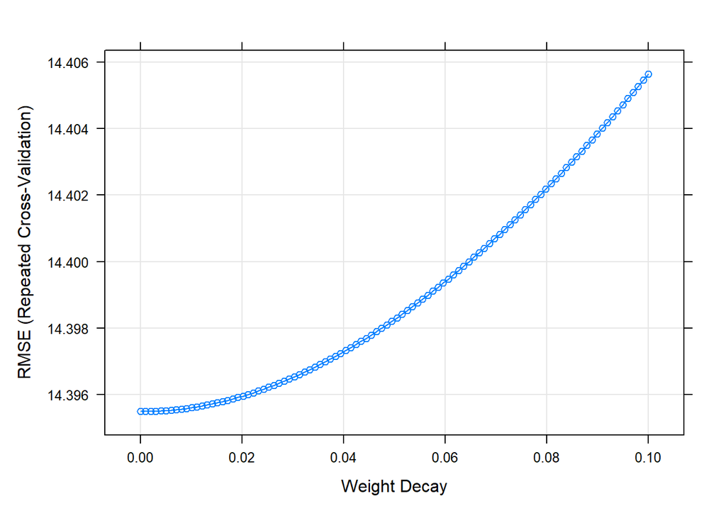

```r
set.seed(123)

ridge_grid <- expand.grid(lambda = seq(0, .1, length = 100))

ridge_tune <- train(model, data = dataTrain,
                    method='ridge',
                    preProc=c('scale','center'),
                    tuneGrid = ridge_grid,
                    trControl=ctrl)
plot(ridge_tune)
```

**Best value for lambda**

When searching the best value for lambda, we search for the least value as we control with it the penalty term, so the higher it is, the bigger is the penalty and the magnitude of the coefficients is reduced.

```r
set.seed(123)

ridge_tune$bestTune
```

```
##        lambda
## 2 0.001010101
```

In this case it is 0.001.

**Prediction**

```r
set.seed(123)

test_results$ridge <- predict(ridge_tune, dataTest)

postResample(pred = test_results$ridge,  obs = test_results$popularity)
```

```
##       RMSE   Rsquared        MAE
## 14.1761361  0.3159339 11.1001193
```

This model gives a R_squared of 0,315 and a RMSE of 14.17. It is a bit higher but still very low.

## Lasso

Lasso regression stands for Least Absolute Shrinkage and Selection Operator, what means that it is based on shrinkage, what means that the data values are centered to a point.

In this model, we also predict the best value for lambda.

**Train and plot the model**

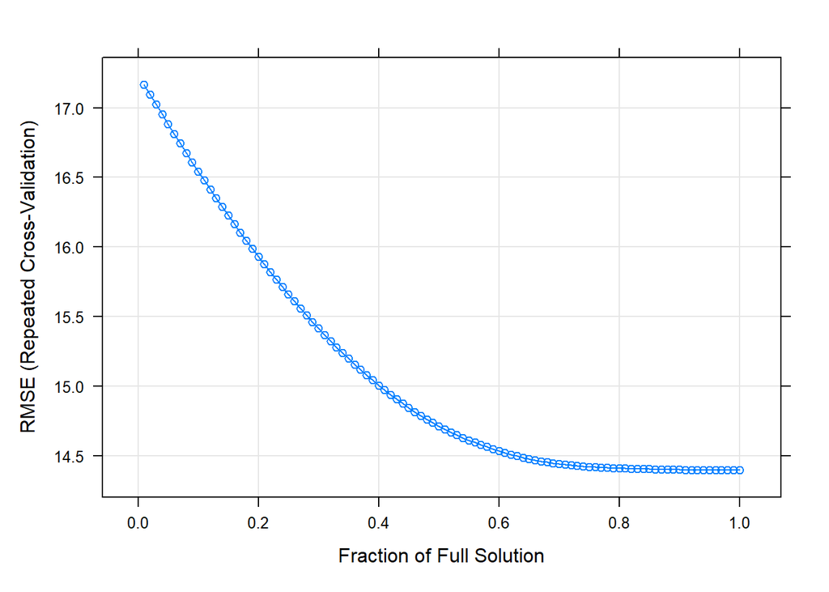

```r
set.seed(123)

lasso_grid <- expand.grid(fraction = seq(.01, 1, length = 100))

lasso_tune <- train(model, data = dataTrain,
                    method='lasso',
                    preProc=c('scale','center'),
                    tuneGrid = lasso_grid,
                    trControl=ctrl)

plot(lasso_tune)
```

**Best value for lambda**

Again, a lower value for lambda indicates that parameters are not eliminated, but as it increases, bias and variance increase too.

```r
set.seed(123)

lasso_tune$bestTune
```

```
##     fraction
## 100        1
```

**Prediction**

```r
set.seed(123)

test_results$lasso <- predict(lasso_tune, dataTest)
postResample(pred = test_results$lasso,  obs = test_results$popularity)
```

```
##      RMSE  Rsquared       MAE
## 14.176098  0.315939 11.100178
```

The predictions are very similar to the last method, with a RMSE of 14.17 and a R-Squared of 0.315.

## Elastic Net

Elastic Net combines the Lasso and ridge techniques. IT combines both regressions to learn from their shortcomings to improve the models and overcome the limitations they present. It uses both alpha and lambda in the grid as we have to get the best value of these parameters.

**Train and plot the model**

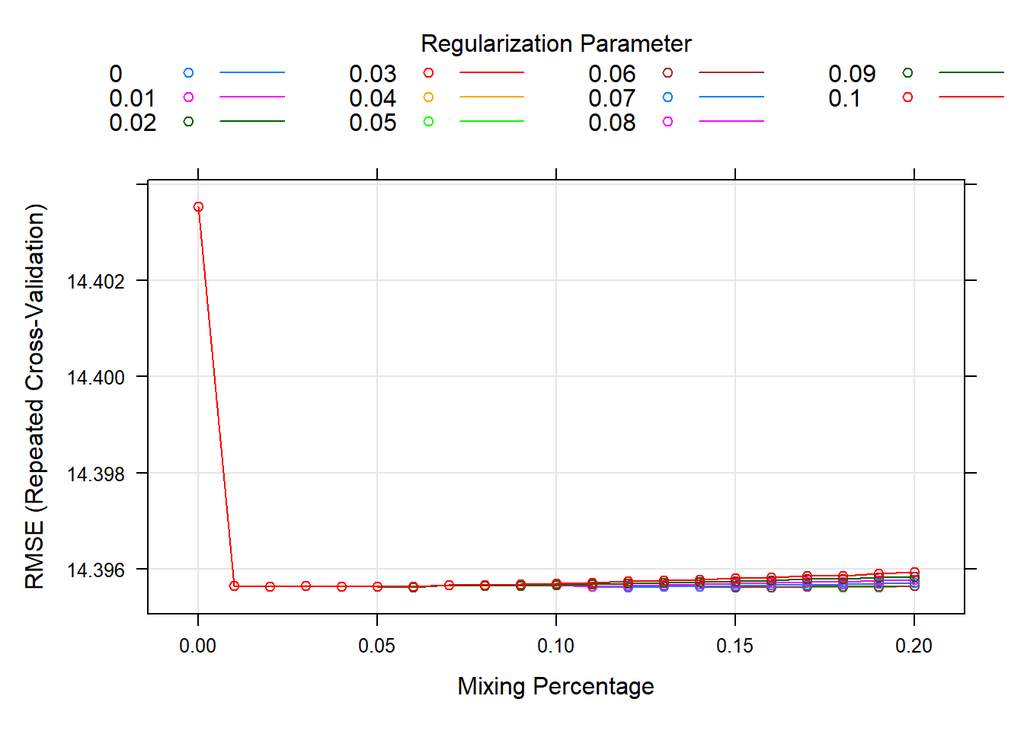

```r
set.seed(123)

elastic_grid = expand.grid(alpha = seq(0, .2, 0.01), lambda = seq(0, .1, 0.01))

glmnet_tune <- train(model, data = dataTrain,
                     method='glmnet',
                     preProc=c('scale','center'),
                     tuneGrid = elastic_grid,
                     trControl=ctrl)

plot(glmnet_tune)
```

**Best values**

```r
set.seed(123)

glmnet_tune$bestTune
```

```
##    alpha lambda
## 76  0.06   0.09
```

This technique predicts that the best values are 0.06 for alpha, and 0.09 for lambda.

**Prediction**

```r
set.seed(123)

test_results$glmnet <- predict(glmnet_tune, dataTest)

postResample(pred = test_results$glmnet,  obs = test_results$popularity)
```

```
##       RMSE   Rsquared        MAE
## 14.1764515  0.3159497 11.1050629
```

The R-Squared is of 0.315, which is a very low value. Also, the error is of 14.17.

# Machine learning tools

As we did on the classification approach, we are also going to apply machine learning methods that predict now the value of our numerical variable.

## kNN

kNN (k nearest neighbors) is a method based on the idea that the values that are the closest to the data are more similar, so new values can be predicted using the closest existing ones. We choose the number of nearby observation with the k value. In our grid, it is defined at the kmax parameter.

**Training**

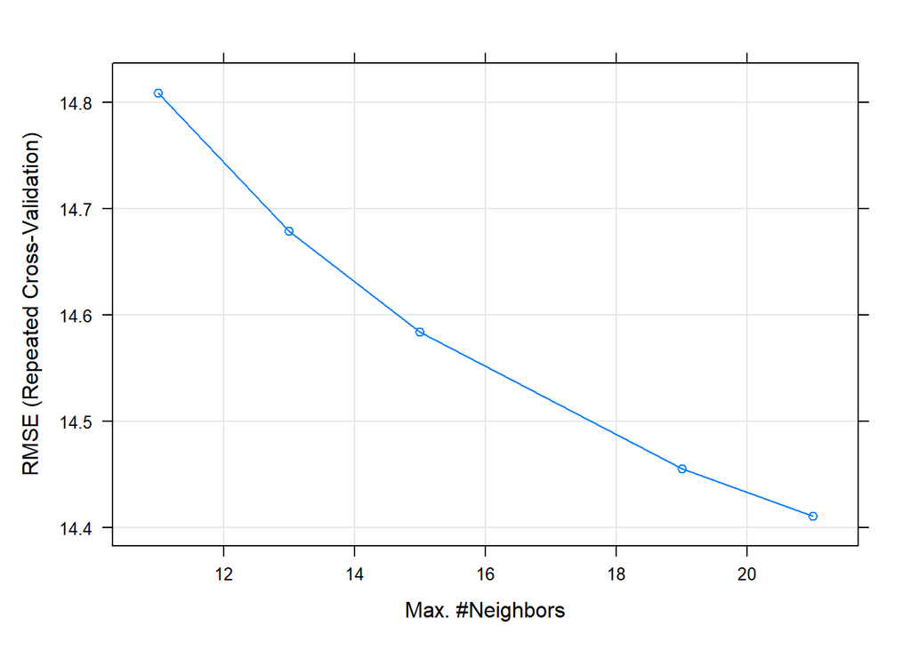

```r
set.seed(123)

knn_tune <- train(model,
                  data = dataTrain,
                  method = "kknn",
                  preProc=c('scale','center'),
                  tuneGrid = data.frame(kmax=c(11,13,15,19,21),distance=2,kernel='optimal'),
                  trControl = ctrl)
plot(knn_tune)
```

With this plot, we can see how the error changes when the value of k is altered. As it could be expected, the error decreases when the number of neighbors increases, as the precision is higher with more observations.

**Predict**

```r
set.seed(123)

test_results$knn <- predict(knn_tune, dataTest)

postResample(pred = test_results$knn,  obs = test_results$popularity)
```

```
##       RMSE   Rsquared        MAE
## 14.2010840  0.3157602 11.0993213
```

The results of this model give an R-Squared of 0.315, and an error (RMSE) of 14.2, what means that this model is not very accurate and there may be other better.

## Random Forests

As explained before, random forest is a combination of decision trees. In this case, we use 100 trees and the mtry (number of random variables) hyperparameter.

```r
set.seed(123)

rf_tune <- train(model,
                 data = dataTrain,
                 method = "rf",
                 preProc=c('scale','center'),
                 trControl = ctrl,
                 ntree = 100,
                 tuneGrid = data.frame(mtry=c(1,3,5,7)),
                 importance = TRUE)

plot
```

[output not shown]

```r
(rf_tune)
```

```
## Random Forest
##
## 47956 samples
##     7 predictor
##
## Pre-processing: scaled (7), centered (7)
## Resampling: Cross-Validated (5 fold, repeated 1 times)
## Summary of sample sizes: 38364, 38364, 38365, 38365, 38366
## Resampling results across tuning parameters:
##
##   mtry  RMSE      Rsquared   MAE
##   1     13.97701  0.3447639  10.96809
##   3     13.91401  0.3490015  10.79748
##   5     13.95502  0.3454832  10.82322
##   7     13.97559  0.3437719  10.84141
##
## RMSE was used to select the optimal model using the smallest value.
## The final value used for the model was mtry = 3.
```

**Predict**

```r
test_results$rf <- predict(rf_tune, dataTest)

postResample(pred = test_results$rf,  obs = test_results$popularity)
```

```
##       RMSE   Rsquared        MAE
## 13.6061430  0.3698362 10.5886478
```

This model gives an R-Squared of 0.369 and an error of 13.6, which are better values than the kNN, although these values are not good enough.

## Gradient Boosting

As explained at the gradient boosting computed before, it is a combination of weak learners (decision trees).

```r
set.seed(123)

xgb_tune <- train(model,
                  data = dataTrain,
                  method = "xgbTree",
                  preProc=c('scale','center'),
                  objective="reg:squarederror",
                  trControl = ctrl,
                  tuneGrid = expand.grid(nrounds = c(500,1000), max_depth = c(5,6,7), eta = c(0.01, 0.1, 1),
                                         gamma = c(1, 2, 3), colsample_bytree = c(1, 2),
                                         min_child_weight = c(1), subsample = c(0.2,0.5,0.8)))
```

[output not shown]

[output cut: 350 more lines]

[output not shown]

**Predict**

```r
test_results$xgb <- predict(xgb_tune, dataTest)

postResample(pred = test_results$xgb,  obs = test_results$popularity)
```

```
##       RMSE   Rsquared        MAE
## 13.4785314  0.3816703 10.4643118
```

This gives an R-Squared of 0.381, which is similar to the other results. Regarding error, it has a value of 13.47.

## Ensemble

As before, ensemble is going to combine the previously obtained results to create a new one.

```r
set.seed(123)

apply(test_results[-1], 2, function(x) mean(abs(x - test_results$popularity)))
```

```
##       lm      alm    ridge    lasso   glmnet      knn       rf      xgb
## 11.10018 11.10018 11.10012 11.10018 11.10506 11.09932 10.58865 10.46431
```

**Prediction**

```r
test_results$comb = (test_results$alm + test_results$knn + test_results$rf)/3

postResample(pred = test_results$comb,  obs = test_results$popularity)
```

```
##       RMSE   Rsquared        MAE
## 13.7098618  0.3612193 10.7260312
```

Ensemble values give a value of 0.361 at the R-Squared and 13.7 at the error.

## Conclusions

Regardless of that, if I had to choose one of the models, taking into account the values of the R-Squared and the error, I would select the gradient boosting that has an R-Squared of 0.381, being the highest among all, and the error that it has is the lowest one. However, the model would still not be able to predict correctly our study variable.

# Overall conclusions

After training both models for predicting categorical and numerical variables, I have come to the conclusion that predicting a categorical one is easier, what is logical as it has less values so it is more precise. Also, it is important to have balanced classes as it provides better results and it is also crucial to select a good range of variables that can predict your variable although sometimes, if bad values are obtained, it concludes that the variables of your dataset cannot explain correctly your subject of study. Taking this into account, it is also important the correlations between the variables, as if many variables are very correlated, they represent the same and they are redundant so some can be erased without losing information.

Another important point is to select the best model, as there are many techniques and each concrete case can have a different optimal one. To choose it, first the best values for the hyperparameters should be obtained so that the model is the best possible. Once the models are obtained, both the accuracies or R-Squared must be checked, but also the cost. This is important because a very consuming method is not preferable, so the best combination of both characteristics should be chosen.

Regarding the conclusions of this Spotify tracks dataset, I have discovered the importance of the year the song was created at, as more recent songs have a way bigger popularity than older ones. Also, it is the most correlated variable with the popularity, and the most important one taking into account the variable importance plot. Regardless of that, other important variables have to do with the configurations of the song in the sense of the volume and the electronic instruments they use. This makes me think that, as Spotify is mainly used among young users, loud songs that include electronic instruments are popular because of them. This idea is reinforced by the fact that the energy and danceability of the songs is also a crucial factor. On the contrary, variables such as the mode and key do not seem that important, which are related to the ‘musical’ part of the song, as they are the notes and modalities (major and manor) of the tracks.

# Bibliography

I have based my work on the notebooks present at Aula Global and I have searched for imformation regarding Spotify’s parameters at its API documentation.